# Contextual Familiarity Rescues the Cost of Switching: Experiment 1

## R Markdown

```r
#Load in libraries
library(tidyverse)
library(rio)
library(plyr)
library(dplyr)
library(fs)
library(lme4)
library(lmerTest)
library(psych)
```

```r
options(scipen=999)
library(ggplot2)
library(sjPlot)
library(stats)
library(plotrix)
```

#ENCODING

```r
#loading in data

switch11 <- import("switchfreq_11_main_raw_21_02_21.csv")

#filter out subjects who are not included in final sample
# Create a vector of subjects to exclude
excluded_subjects <- c(
  '135805', '141694', '149968', '154129', '155302', '156577', '156625', '156892',
  '156919', '156967', '157111', '157219', '157225', '157228', '157243', '157426',
  '157441', '157522', '157552', '157576', '157585', '157681', '742243851',
  '157843', '742243853', '157771'
)

# Filter out subjects in one step
switch11_use <- switch11 %>%
  filter(!subject %in% excluded_subjects)


#filter out the math distractor task to include only the encoding data
sf11_total_encodingonly <-  switch11_use %>%
  filter(str_detect(trialcode, "image"))
```

```r
#add in columns to data set
sf11_total_encodingonly_new <- sf11_total_encodingonly %>%
 mutate(blocknum_contin = case_when(blocknum == "11" ~ "1",
                                         blocknum == "15" ~"2",
                                         blocknum == "19" ~"3",
                                         blocknum == "23" ~"4",
                                      blocknum == "27" ~ "5",
                                         blocknum == "31" ~"6",
                                         blocknum == "35" ~"7",
                                         blocknum == "39" ~"8")) %>%
  mutate(list_half = case_when(trialnum == "1" ~ "first_half",
                                         trialnum == "2" ~"first_half",
                                         trialnum == "3" ~"first_half",
                                         trialnum == "4" ~"first_half",
                                         trialnum == "5" ~ "first_half",
                                         trialnum == "6" ~"first_half",
                                         trialnum == "7" ~"first_half",
                                         trialnum == "8" ~"first_half",
                                         trialnum == "9" ~"first_half",
                                         trialnum == "10" ~"first_half",
                                         trialnum == "11" ~"first_half",
                                         trialnum == "12" ~ "first_half",
                                         trialnum == "13" ~"second_half",
                                         trialnum == "14" ~"second_half",
                                         trialnum == "15" ~"second_half",
                                          trialnum == "16" ~"second_half",
                                         trialnum == "17" ~"second_half",
                                         trialnum == "18" ~"second_half",
                                          trialnum == "19" ~"second_half",
                                         trialnum == "20" ~"second_half",
                                         trialnum == "21" ~"second_half",
                                          trialnum == "22" ~"second_half",
                                         trialnum == "23" ~"second_half",
                                         trialnum == "24" ~"second_half")) %>%
  mutate(condition_control = case_when(condition == "cont_mid" ~ "no switch",
                                         condition == "cont_high" ~"no switch",
                                         condition == "high" ~"switch",
                                         condition == "mid" ~"switch")) %>%
  mutate(condition_mh = case_when(condition == "cont_mid" ~ "mid",
                                         condition == "cont_high" ~"high",
                                         condition == "high" ~"high",
                                         condition == "mid" ~"mid")) %>%
    mutate(pool_number = case_when(word_enc == "ACORN"~ 1,
word_enc == "ANCHOR"~   2,
word_enc =="APPLE"  ~3,
word_enc =="APRON"  ~4,
word_enc =="ARROW"~ 5,
word_enc =="ATLAS"~ 6,
word_enc =="BACON"~ 7,
word_enc =="BAKER"~ 8,
word_enc =="BANDAGE"~ 9,
word_enc =="BANJO"~ 10,
word_enc =="BANKER"~    11,
word_enc =="BARLEY"~    12,
word_enc =="BARREL"~    13,
word_enc =="BASEBALL"~  14,
word_enc =="BEAKER"~    15,
word_enc =="BEAVER"~    16,
word_enc =="BEETLE"~    17,
word_enc =="BERRY"~ 18,
word_enc =="BINDER"~    19,
word_enc =="BISCUIT"~   20,
word_enc =="BISON"~ 21,
word_enc =="BLACKBOARD"~    22,
word_enc =="BLENDER"~   23,
word_enc =="BOTTLE"~    24,
word_enc =="BRACELET"~  25,
word_enc =="BRIEFCASE"~ 26,
word_enc =="BUILDING"~  27,
word_enc =="BUTLER"~    28,
word_enc =="BUTTER"~    29,
word_enc =="BUTTON"~    30,
word_enc =="CABBAGE"~   31,
word_enc =="CACTUS"~    32,
word_enc =="CAMEL"~ 33,
word_enc =="CANDY"~ 34,
word_enc =="CANOE"~ 35,
word_enc =="CANVAS"~    36,
word_enc =="CARPET"~    37,
word_enc =="CARROT"~    38,
word_enc =="CARTON"~    39,
word_enc =="CASTLE"~    40,
word_enc =="CATTLE"~    41,
word_enc =="CELLO"~ 42,
word_enc =="CHECKERS"~  43,
word_enc =="CHEDDAR"~   44,
word_enc =="CHERRY"~    45,
word_enc =="CHICKEN"~   46,
word_enc =="CHIPMUNK"~  47,
word_enc =="CLOSET"~    48,
word_enc =="COFFEE"~    49,
word_enc =="COMPASS"~   50,
word_enc =="COOKBOOK"~  51,
word_enc =='COOKIE'~    52,
word_enc =="COOLER"~    53,
word_enc =="CORAL"~ 54,
word_enc =="COTTAGE"~   55,
word_enc =="COTTON"~    56,
word_enc =="CRACKER"~   57,
word_enc =="CRAYON"~    58,
word_enc =="CRICKET"~   59,
word_enc =="CRYSTAL"~   60,
word_enc =="CURTAIN"~   61,
word_enc =="CUSHION"~   62,
word_enc =="DAISY"~ 63,
word_enc =="DENIM"~ 64,
word_enc =="DENTIST"~   65,
word_enc =="DESSERT"~   66,
word_enc =="DIAPER"~    67,
word_enc =="DINNER"~    68,
word_enc =="DOLLAR"~    69,
word_enc =="DOLPHIN"~   70,
word_enc =="DONKEY"~    71,
word_enc =="DOORBELL"~  72,
word_enc =="DOUGHNUT"~  73,
word_enc =="DRAWING"~   74,
word_enc =="DRESSER"~   75,
word_enc =="DRIVEWAY"~  76,
word_enc =="DUSTPAN"~   77,
word_enc =="EAGLE"~ 78,
word_enc =="EARRING"~   79,
word_enc =="ENGINE"~    80,
word_enc =="ESSAY"~ 81,
word_enc =="FAUCET"~    82,
word_enc =="FEATHER"~   83,
word_enc =="FLANNEL"~   84,
word_enc =="FLASHLIGHT"~    85,
word_enc =="FOLDER"~    86,
word_enc =="FOOTBALL"~  87,
word_enc =="FOREST"~    88,
word_enc =="FOSSIL"~    89,
word_enc =="FOUNTAIN"~  90,
word_enc =="FREEZER"~   91,
word_enc =="GARBAGE"~   92,
word_enc =="GARDEN"~    93,
word_enc =="GARLIC"~    94,
word_enc =="GIRAFFE"~   95,
word_enc =="GUITAR"~    96,
word_enc =="GYMNAST"~   97,
word_enc =="HAMMER"~    98,
word_enc =="HAMMOCK"~   99,
word_enc =="HAMPER"~    100,
word_enc =="HANDBAG"~   101,
word_enc =="HANGER"~    102,
word_enc =="HEADBAND"~  103,
word_enc =="HELMET"~    104,
word_enc =="HIGHWAY"~   105,
word_enc =="HIKER"~ 106,
word_enc =="HONEY"~ 107,
word_enc =="IRON"~  108,
word_enc =="JACKET"~    109,
word_enc =="JELLY"~ 110,
word_enc =="JEWEL"~ 111,
word_enc =="KETCHUP"~   112,
word_enc =="KETTLE"~    113,
word_enc =="KEYBOARD"~  114,
word_enc =="KITCHEN"~   115,
word_enc =="LADDER"~    116,
word_enc =="LAUNDRY"~   117,
word_enc =="LAVA"~  118,
word_enc =="LAWYER"~    119,
word_enc =="LEMON"~ 120,
word_enc =="LEOPARD"~   121,
word_enc =="LETTER"~    122,
word_enc =="LETTUCE"~   123,
word_enc =="LINEN"~ 124,
word_enc =="LION"~  125,
word_enc =="LIPSTICK"~  126,
word_enc =="LITTER"~    127,
word_enc =="LIZARD"~    128,
word_enc =="LUGGAGE"~   129,
word_enc =="LUMBER"~    130,
word_enc =="MACHINE"~   131,
word_enc =="MAILBOX"~   132,
word_enc =="MARBLE"~    133,
word_enc =="MATTRESS"~  134,
word_enc =="MIRROR"~    135,
word_enc =="MITTEN"~    136,
word_enc =="MONKEY"~    137,
word_enc =="MOUNTAIN"~  138,
word_enc =="MUFFIN"~    139,
word_enc =="MUSHROOM"~  140,
word_enc =="NAPKIN"~    141,
word_enc =="NECKLACE"~  142,
word_enc =="NEEDLE"~    143,
word_enc =="NICKEL"~    144,
word_enc =="NOVEL"~ 145,
word_enc =="OATMEAL"~   146,
word_enc =="OLIVE"~ 147,
word_enc =="OMELET"~    148,
word_enc =="ONION"~ 149,
word_enc =="ORANGE"~    150,
word_enc =="ORCHID"~    151,
word_enc =="OTTER"~ 152,
word_enc =="OUTFIT"~    153,
word_enc =="OVEN"~  154,
word_enc =="OWL"~   155,
word_enc =="OYSTER"~    156,
word_enc =="PACKAGE"~   157,
word_enc =="PADDLE"~    158,
word_enc =="PAINTING"~  159,
word_enc =="PANTHER"~   160,
word_enc =="PARSLEY"~   161,
word_enc =="PASTA"~ 162,
word_enc =="PASTRY"~    163,
word_enc =="PEANUT"~    164,
word_enc =="PEBBLE"~    165,
word_enc =="PENCIL"~    166,
word_enc =="PENGUIN"~   167,
word_enc =="PENNY"~ 168,
word_enc =="PEPPER"~    169,
word_enc =="PICKLE"~    170,
word_enc =="PICNIC"~    171,
word_enc =="PIGEON"~    172,
word_enc =="PILLOW"~    173,
word_enc =="PILOT"~ 174,
word_enc =="PIZZA"~ 175,
word_enc =="PLANET"~    176,
word_enc =="PLAYGROUND"~    177,
word_enc =="POPCORN"~   178,
word_enc =="POSSUM"~    179,
word_enc =="PRINTER"~   180,
word_enc =="PUDDING"~   181,
word_enc =="PUDDLE"~    182,
word_enc =="PUMPKIN"~   183,
word_enc =='PUZZLE'~    184,
word_enc =="RABBIT"~    185,
word_enc =="RACCOON"~   186,
word_enc =="RACKET"~    187,
word_enc =="RADISH"~    188,
word_enc =="RAILROAD"~  189,
word_enc =="RAISIN"~    190,
word_enc =="RATTLE"~    191,
word_enc =="RECEIPT"~   192,
word_enc =="RECORD"~    193,
word_enc =="REPORT"~    194,
word_enc =="RIBBON"~    195,
word_enc =="RIVER"~ 196,
word_enc =="ROBOT"~ 197,
word_enc =="RUNNER"~    198,
word_enc =="SADDLE"~    199,
word_enc =="SAILOR"~    200,
word_enc =="SALAD"~ 201,
word_enc =="SALMON"~    202,
word_enc =="SANDWICH"~  203,
word_enc =="SEAFOOD"~   204,
word_enc =="SEASHORE"~  205,
word_enc =="SHAMPOO"~   206,
word_enc =="SHOELACE"~  207,
word_enc =="SHOVEL"~    208,
word_enc =="SHOWER"~    209,
word_enc =="SIDEWALK"~  210,
word_enc =="SNORKEL"~   211,
word_enc =="SODA"~  212,
word_enc =="SOFA"~  213,
word_enc =="SQUIRREL"~  214,
word_enc =="STATUE"~    215,
word_enc =="STICKER"~   216,
word_enc =="STOCKING"~  217,
word_enc =="SUGAR"~ 218,
word_enc =="SUITCASE"~  219,
word_enc =="SUNRISE"~   220,
word_enc =="SWEATER"~   221,
word_enc =="TABLE"~ 222,
word_enc =="TEACHER"~   223,
word_enc =="TOASTER"~   224,
word_enc =="TOOTHBRUSH"~    225,
word_enc =="TOURIST"~   226,
word_enc =="TOWEL"~ 227,
word_enc =="TOWER"~ 228,
word_enc =="TUBA"~  229,
word_enc =="TULIP"~ 230,
word_enc =="TURNIP"~    231,
word_enc =="TURTLE"~    232,
word_enc =="VACUUM"~    233,
word_enc =="VALLEY"~    234,
word_enc =="VELVET"~    235,
word_enc =="WAGON"~ 236,
word_enc =="WALNUT"~    237,
word_enc =="WALRUS"~    238,
word_enc =="WASHCLOTH"~ 239,
word_enc =="ZIPPER"~    240))

sf11_total_encodingonly_new$blocknum_contin <- as.integer(sf11_total_encodingonly_new$blocknum_contin )
```

```r
#encoding task

detach(package:plyr)


Mode <- function(x) {
  ux <- unique(x)
  ux[which.max(tabulate(match(x, ux)))]
}


encoding_sf11_avg <- sf11_total_encodingonly_new %>%
  group_by(image, word_enc) %>%
  mutate(resp_mode = Mode(response)) %>%  #takes the mode of responses based on word and trial
  mutate(similar_to_avg = case_when(response == resp_mode ~ 1, #when the response is the mode - 1
                               response != resp_mode ~ 0)) %>% #when response is not the mode - 0
  arrange(subject, blocknum) %>% #arranges it back by subject
  group_by(subject, blocknum) %>%
  mutate(sum_encoding_sim = sum(similar_to_avg)) #creates a sum by block


encoding_sf11_avg_2 <- encoding_sf11_avg %>%
  group_by(subject) %>%
  mutate(similar_to_avg_percent = sum(similar_to_avg)/192*100) %>%
  summarise(mean_enc = mean(similar_to_avg_percent, na.rm = TRUE))

#Calculate average encoding not based on trialcode, but based on actual stimuli on the screen (in column "image"). This is because of the way I coded it, the item in trialcode maps to multiple images. Therefore, Image is the column needed to determine which "task" the participants are performing on that trial

#chance is 55.7% for 192 trials

mean_encoding_11 <- mean(encoding_sf11_avg_2$mean_enc, na.rm = TRUE)
mean_encoding_11
```

```
## [1] 89.53993
```

```r
#create separate dataframes for between subjects manipulations
#between subjects manipulation here is same vs novel NOT high vs mid

#removes switch from control also

sf11_total_encodingonly_between <- encoding_sf11_avg %>%
  mutate(between_condition = case_when(blockcode == "control_mid_same" ~ "same",
                                         blockcode == "control_high_same" ~"same",
                                         blockcode == "high_control_same" ~"same",
                                         blockcode == "mid_control_same" ~"same",
                                       blockcode == "control_mid_novel" ~ "novel",
                                         blockcode == "control_high_novel" ~"novel",
                                         blockcode == "high_control_novel" ~"novel",
                                         blockcode == "mid_control_novel" ~"novel")) %>%
  filter(task_switch == "switch" & condition == "high"|task_switch == "repeat" & condition == "high"|task_switch == "start" & condition == "high"| task_switch == "switch" & condition == "mid"| task_switch == "repeat" & condition == "mid"| task_switch == "start" & condition == "mid"|task_switch == "repeat" & condition == "cont_high"| task_switch == "start" & condition == "cont_high"| task_switch == "repeat" & condition == "cont_mid"| task_switch == "start" & condition == "cont_mid")



sf11_total_encodingonly_same <-sf11_total_encodingonly_between %>%
  filter(between_condition == "same")


sf11_total_encodingonly_novel <-sf11_total_encodingonly_between %>%
  filter(between_condition == "novel")
```

```r
#compare mean encoding performance between same and novel

encoding_sf11_avg_3 <- sf11_total_encodingonly_between %>%
  group_by(subject, between_condition) %>%
  mutate(similar_to_avg_percent = sum(similar_to_avg)/192*100) %>%
  summarise(mean_enc = mean(similar_to_avg_percent, na.rm = TRUE))
mean_encoding_11_2 <- mean(encoding_sf11_avg_3$mean_enc, na.rm = TRUE)
mean_encoding_11_2
```

```
## [1] 87.71081
```

```r
encoding_sf11_avg_3_same <- encoding_sf11_avg_3 %>%
  filter(between_condition == "same")

mean_encoding_11_same <- mean(encoding_sf11_avg_3_same$mean_enc, na.rm = TRUE)
mean_encoding_11_same
```

```
## [1] 87.71596
```

```r
sd_same <-sd(encoding_sf11_avg_3_same$mean_enc, na.rm = TRUE)


se_same <- sd_same / sqrt(41)


encoding_sf11_avg_3_novel <- encoding_sf11_avg_3 %>%
  filter(between_condition == "novel")

mean_encoding_11_novel <- mean(encoding_sf11_avg_3_novel$mean_enc, na.rm = TRUE)
mean_encoding_11_novel
```

```
## [1] 87.70591
```

```r
sd_novel <-sd(encoding_sf11_avg_3_novel$mean_enc, na.rm = TRUE)


se_novel <- sd_novel / sqrt(43)



t.test(encoding_sf11_avg_3_same$mean_enc, encoding_sf11_avg_3_novel$mean_enc)
```

```
##
##  Welch Two Sample t-test
##
## data:  encoding_sf11_avg_3_same$mean_enc and encoding_sf11_avg_3_novel$mean_enc
## t = 0.0076557, df = 81.419, p-value = 0.9939
## alternative hypothesis: true difference in means is not equal to 0
## 95 percent confidence interval:
##  -2.600273  2.620362
## sample estimates:
## mean of x mean of y
##  87.71596  87.70591
```

```r
library(lsr)

cohensD(mean_enc ~ between_condition,data = encoding_sf11_avg_3)
```

```
## [1] 0.001672537
```

So far, we found that accuracy during the encoding task did not not differ for repeated and novel context switches

```r
#sets path to data
#changes ann files to txt files
path_to_data <- "~/Documents/DuBrow_lab/Projects/Multitasking/switchfreq_11/Raw_Data"
setwd(path_to_data)
ann_files <- list.files(path_to_data, recursive = TRUE, pattern = "*.ann", full.names = TRUE)
text_files <- gsub(".ann", ".txt", ann_files)
text_files
```

```
## character(0)
```

```r
file.rename(from= ann_files, to = text_files)
```

```
## logical(0)
```

```r
library(plyr)
# Define the list of subject IDs explicitly
subjects <- c("137455", "138853", "139435", "142837", "145912", "146857", "148570", "149335",
  "149395", "149437", "149512", "150661", "151762", "151921", "152983", "153382",
  "154174", "154264", "154348", "154444", "154801", "154906", "154984", "155560",
  "156130", "156385", "156418", "156436", "156541", "156544", "156550", "156586",
  "156595", "156604", "156691", "156739", "156751", "156784", "156961", "156970",
  "156979", "156988", "157000", "157027", "157057", "157063", "157069", "157159",
  "157171", "157198", "157210", "157261", "157270", "157327", "157339", "157354",
  "157381", "157411", "157432", "157435", "157438", "157447", "157456", "157471",
  "157474", "157486", "157489", "157498", "157549", "157603", "157621", "157639",
  "157648", "157663", "157696", "157837", "157912", "158350", "742243848",
  "742243852", "742243854", "154438", "157246", "152818")

process_subject_data <- function(subject_id) {
  # Define the path to the subject's recall files
  recall_files <- dir_ls(paste0("~/Documents/DuBrow_lab/Projects/Multitasking/switchfreq_11/V1/Raw_data/", subject_id), glob = "*.txt")

  # Load the recall data
  recall_data <- ldply(recall_files, function(f) import(f, quote = ""))

  # Clean the .id column
  recall_data <- recall_data %>%
    mutate(.id = str_replace_all(.id, "/Users/lrait/Documents/DuBrow_lab/Projects/Multitasking/switchfreq_11/V1/Raw_data/", ""))

  # Separate final recall data and other recall data
  final_recall <- recall_data %>%
    filter(.id == paste0(subject_id, "/", "finalrecall.txt"))

  recall <- recall_data %>%
    filter(!grepl(paste0(subject_id, "/", "finalrecall.txt"), .id))

  list(final_recall = final_recall, recall = recall)
}

# Process data for each subject and assign to individual variables
for (subject_id in subjects) {
  data <- process_subject_data(subject_id)

  assign(paste0("recall_data_final_", subject_id), data$final_recall)
  assign(paste0("recall_", subject_id), data$recall)
}
```

#IMMEDIATE RECALL

```r
#most important code chunk.- immediate recall
library(stringr)
detach(package:plyr) #MUST RUN THIS

split_enc_11 <- split(sf11_total_encodingonly_between,sf11_total_encodingonly_between$subject)

#list of all subjects individual recall data
recall11_df_immed = list(recall_137455,recall_138853, recall_139435, recall_142837, recall_145912, recall_146857, recall_148570, recall_149335, recall_149395, recall_149437, recall_149512, recall_150661, recall_151762, recall_151921, recall_152983, recall_153382, recall_154174, recall_154264, recall_154348, recall_154444, recall_154801, recall_154906, recall_154984, recall_155560, recall_156130, recall_156385, recall_156418, recall_156436, recall_156541, recall_156544, recall_156550, recall_156586, recall_156595, recall_156604, recall_156691, recall_156739, recall_156751, recall_156784, recall_156961, recall_156970, recall_156979, recall_156988, recall_157000, recall_157027, recall_157057, recall_157063, recall_157069, recall_157159, recall_157171, recall_157198, recall_157210, recall_157261, recall_157270, recall_157327, recall_157339, recall_157354,recall_157381, recall_157411, recall_157432, recall_157435, recall_157438, recall_157447, recall_157456, recall_157471, recall_157474, recall_157486, recall_157489, recall_157498, recall_157549, recall_157603, recall_157621, recall_157621, recall_157639, recall_157648, recall_157663, recall_157696, recall_157837, recall_157912, recall_158350, recall_742243848, recall_742243852, recall_742243854, recall_154438, recall_157246, recall_152818)


#list of task data
sf11_by_sub <- list(split_enc_11$'137455',split_enc_11$'138853', split_enc_11$'139435', split_enc_11$'142837', split_enc_11$'145912', split_enc_11$'146857', split_enc_11$'148570', split_enc_11$'149335', split_enc_11$'149395', split_enc_11$'149437', split_enc_11$'149512', split_enc_11$'150661', split_enc_11$'151762', split_enc_11$'151921', split_enc_11$'152983', split_enc_11$'153382', split_enc_11$'154174', split_enc_11$'154264', split_enc_11$'154348', split_enc_11$'154444', split_enc_11$'154801', split_enc_11$'154906', split_enc_11$'154984', split_enc_11$'155560', split_enc_11$'156130', split_enc_11$'156385', split_enc_11$'156418', split_enc_11$'156436', split_enc_11$'156541', split_enc_11$'156544', split_enc_11$'156550', split_enc_11$'156586', split_enc_11$'156595', split_enc_11$'156604', split_enc_11$'156691', split_enc_11$'156739', split_enc_11$'156751', split_enc_11$'156784', split_enc_11$'156961', split_enc_11$'156970', split_enc_11$'156979', split_enc_11$'156988', split_enc_11$'157000', split_enc_11$'157027', split_enc_11$'157057', split_enc_11$'157063', split_enc_11$'157069', split_enc_11$'157159', split_enc_11$'157171', split_enc_11$'157198', split_enc_11$'157210', split_enc_11$'157261', split_enc_11$'157270', split_enc_11$'157327', split_enc_11$'157339', split_enc_11$'157354',split_enc_11$'157381', split_enc_11$'157411', split_enc_11$'157432', split_enc_11$'157435', split_enc_11$'157438', split_enc_11$'157447', split_enc_11$'157456', split_enc_11$'157471', split_enc_11$'157474', split_enc_11$'157486', split_enc_11$'157489', split_enc_11$'157498', split_enc_11$'157549', split_enc_11$'157603', split_enc_11$'157621', split_enc_11$'157621', split_enc_11$'157639', split_enc_11$'157648', split_enc_11$'157663', split_enc_11$'157696', split_enc_11$'157837', split_enc_11$'157912', split_enc_11$'158350', split_enc_11$'742243848', split_enc_11$'742243852', split_enc_11$'742243854', split_enc_11$`154438`, split_enc_11$`157246`, split_enc_11$`152818`)


#for every subject:
c = 0
for (ssid in array(1:length(recall11_df_immed))){
    i = sf11_by_sub[[ssid]]
    j = recall11_df_immed[[ssid]]
    c = c +1
    output  <- i %>%
      mutate(recalls = tolower(word_enc) %in% tolower(j$V3))%>%  #matches the recall with task word
      mutate(recalls = case_when(recalls == "TRUE" ~ 1, #if recalled word, puts a 1
                               recalls == "FALSE" ~ 0)) %>%
      group_by(condition, trialcode) %>%
      mutate(sum_recall = sum(recalls)) %>% # this column sums the recalls by condition and task
      group_by(blocknum) %>%
      mutate(sum_recall_block = sum(recalls)) %>% #sums recalls by block
      group_by(trialcode) %>%
      mutate(sum_recall_trialcode = sum(recalls)) #sums recalls just by task
    if (c ==1) {
      sf11_total = output
    } else {
      sf11_total = rbind(sf11_total,output)
    }}

sf11_total
```

```
## # A tibble: 15,980 × 48
## # Groups:   trialcode [30]
##    date       time     subject group blocknum blockcode    condition task_switch
##    <IDate>    <chr>      <int> <int>    <int> <chr>        <chr>     <chr>
##  1 2021-01-17 00:54:37  137455   582       11 control_mid… cont_mid  start
##  2 2021-01-17 00:54:37  137455   582       11 control_mid… cont_mid  repeat
##  3 2021-01-17 00:54:37  137455   582       11 control_mid… cont_mid  repeat
##  4 2021-01-17 00:54:37  137455   582       11 control_mid… cont_mid  repeat
##  5 2021-01-17 00:54:37  137455   582       11 control_mid… cont_mid  repeat
##  6 2021-01-17 00:54:37  137455   582       11 control_mid… cont_mid  repeat
##  7 2021-01-17 00:54:37  137455   582       11 control_mid… cont_mid  repeat
##  8 2021-01-17 00:54:37  137455   582       11 control_mid… cont_mid  repeat
##  9 2021-01-17 00:54:37  137455   582       11 control_mid… cont_mid  repeat
## 10 2021-01-17 00:54:37  137455   582       11 control_mid… cont_mid  repeat
## # ℹ 15,970 more rows
## # ℹ 40 more variables: trialnum <int>, trialcode <chr>, response <chr>,
## #   latency <int>, correct <int>, image <chr>, stimulusitem2 <chr>,
## #   word_enc <chr>, stimulusitem4 <chr>, stimulusitem5 <chr>,
## #   stimulusitem6 <chr>, stimulusitem7 <chr>, mathcorrect <lgl>,
## #   currentsetsize <int>, text.letters.currentitem <chr>,
## #   sentenceproblemcount <int>, text.PracSentenceProblem.currentitem <chr>, …
```

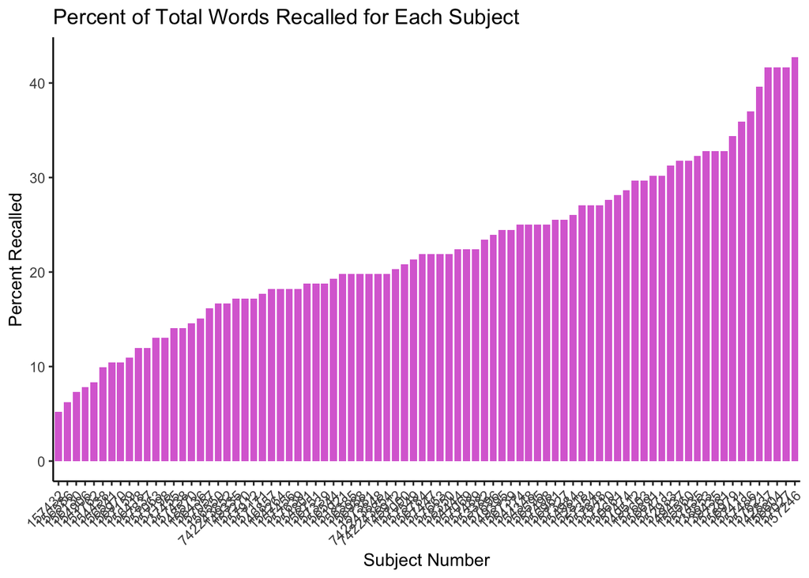

```r
#recall by task - immediate
library(dplyr)

sf11_total_2_immed<- sf11_total %>%
  group_by(subject) %>%
  mutate(recall_percent2 = sum(recalls)/192*100) %>%
  summarise(mean_rec = mean(recall_percent2, na.rm = TRUE))



#plot of each subjects recall in order
sf11_total_2_immed %>%
  ggplot(aes(x = reorder(as.character(subject), mean_rec), y = mean_rec))+
  geom_col(fill = "orchid", width = .8)+
  theme_classic()+
  theme(axis.text.x = element_text(angle = 45,hjust = 1))+
  labs(title    = "Percent of Total Words Recalled for Each Subject",
         x        = "Subject Number",
         y        = "Percent Recalled")
```

```r
mean_recall11<- mean(sf11_total_2_immed$mean_rec, na.rm = TRUE)
mean_recall11
```

```
## [1] 22.45784
```

```r
sd_11 <-sd(sf11_total_2_immed$mean_rec, na.rm = TRUE)
```

```r
#outliers at immed, all participants included
sf11_total_2_immed %>%
  arrange(mean_rec)
```

```
## # A tibble: 84 × 2
##    subject mean_rec
##      <int>    <dbl>
##  1  157432     5.21
##  2  156586     6.25
##  3  156130     7.29
##  4  154906     7.81
##  5  151762     8.33
##  6  154438     9.90
##  7  156541    10.4
##  8  156970    10.4
##  9  157159    10.9
## 10  156418    12.0
## # ℹ 74 more rows
```

```r
sd_11 <-sd(sf11_total_2_immed$mean_rec, na.rm = TRUE)

mean_recall11 <- mean(sf11_total_2_immed$mean_rec, na.rm = TRUE)

mean_recall11 + (2.5 * sd_11)
```

```
## [1] 44.23217
```

```r
mean_recall11 - (2.5 * sd_11)
```

```
## [1] 0.6835034
```

```r
#mean recall between same and novel

sf11_total_2_immed_between<- sf11_total %>%
  group_by(subject, between_condition) %>%
  mutate(recall_percent2 = sum(recalls)/192*100) %>%
  summarise(mean_rec = mean(recall_percent2, na.rm = TRUE))
sf11_total_2_immed_between_same <- sf11_total_2_immed_between %>%
  filter(between_condition == "same")


mean_recall11_same<- mean(sf11_total_2_immed_between_same$mean_rec, na.rm = TRUE)
mean_recall11_same
```

```
## [1] 24.47917
```

```r
sf11_total_2_immed_between_novel <- sf11_total_2_immed_between %>%
  filter(between_condition == "novel")

mean_recall11_novel<- mean(sf11_total_2_immed_between_novel$mean_rec, na.rm = TRUE)
mean_recall11_novel
```

```
## [1] 20.53052
```

```r
t.test(sf11_total_2_immed_between_same$mean_rec, sf11_total_2_immed_between_novel$mean_rec)
```

```
##
##  Welch Two Sample t-test
##
## data:  sf11_total_2_immed_between_same$mean_rec and sf11_total_2_immed_between_novel$mean_rec
## t = 2.1231, df = 81.995, p-value = 0.03676
## alternative hypothesis: true difference in means is not equal to 0
## 95 percent confidence interval:
##  0.2488256 7.6484612
## sample estimates:
## mean of x mean of y
##  24.47917  20.53052
```

```r
cohensD(mean_rec~between_condition, sf11_total_2_immed_between)
```

```
## [1] 0.4628078
```

Free-recall accuracy was greater for repeated versus novel switches suggesting that participants’ memory was better for words from lists containing repeated scenes.

```r
#separate by between condition
sf11_total_2 <-sf11_total %>%
  mutate(between_condition = case_when(blockcode == "control_mid_same" ~ "same",
                                         blockcode == "control_high_same" ~"same",
                                         blockcode == "high_control_same" ~"same",
                                         blockcode == "mid_control_same" ~"same",
                                       blockcode == "control_mid_novel" ~ "novel",
                                         blockcode == "control_high_novel" ~"novel",
                                         blockcode == "high_control_novel" ~"novel",
                                         blockcode == "mid_control_novel" ~"novel")) %>%
  filter(task_switch == "switch" & condition == "high"|task_switch == "repeat" & condition == "high"|task_switch == "start" & condition == "high"| task_switch == "switch" & condition == "mid"| task_switch == "repeat" & condition == "mid"| task_switch == "start" & condition == "mid"|task_switch == "repeat" & condition == "cont_high"| task_switch == "start" & condition == "cont_high"| task_switch == "repeat" & condition == "cont_mid"| task_switch == "start" & condition == "cont_mid") %>%
    mutate(condition_control = case_when(condition == "cont_mid" ~ "no switch",
                                         condition == "cont_high" ~"no switch",
                                         condition == "high" ~"switch",
                                         condition == "mid" ~"switch")) %>%
  mutate(condition_mh = case_when(condition == "cont_mid" ~ "mid",
                                         condition == "cont_high" ~"high",
                                         condition == "high" ~"high",
                                         condition == "mid" ~"mid")) %>%
     mutate(condition_high = case_when(condition == "cont_high" ~"cont_high",
                                         condition == "high" ~"high")) %>%
  mutate(condition_low = case_when(condition == "cont_mid" ~ "cont_mid",
                                         condition == "mid" ~"mid"))


sf11_total_same <- sf11_total_2 %>%
  filter(between_condition == "same")


sf11_total_novel <- sf11_total_2 %>%
  filter(between_condition == "novel")
```

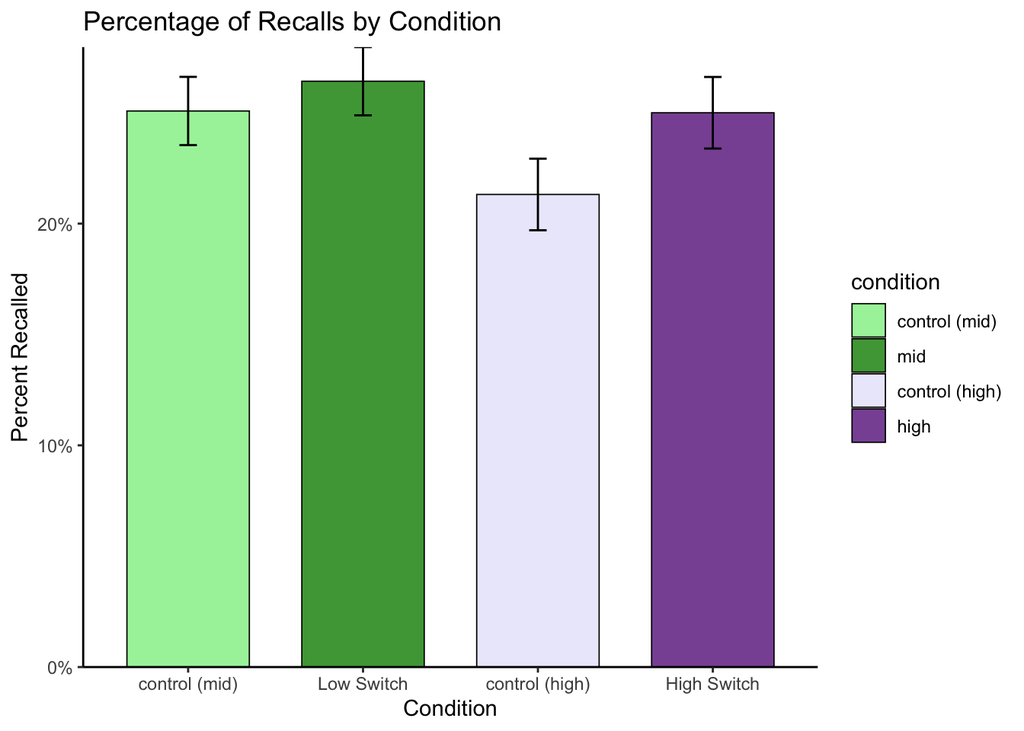

```r
#plot average recalls for task and condition

#separate control into high and mid paired
#no switch items in the control

#difference score error bars same


sf12_total_tally_same_immed <- sf11_total_same %>%
  group_by(subject, condition) %>%
  tally()


sf12_total_same_2 <- sf11_total_same %>%
  dplyr:: select(subject, condition, trialcode, sum_recall, recalls) %>%
  group_by(subject, condition) %>%
  mutate(sum_recall2 = sum(recalls)) %>%
  summarise(mean_rec_cond = mean(sum_recall2))
merged_same <- merge(sf12_total_same_2,sf12_total_tally_same_immed)

merged_same <- merged_same %>%
  mutate(prop_cond = mean_rec_cond/n)

difference_error_same <- merged_same %>%
  dplyr::select(subject, condition, prop_cond) %>%
  reshape(idvar = "subject", timevar = "condition", direction = "wide") %>%
  group_by(subject) %>%
  mutate(diff_cont_high = sum(prop_cond.high- prop_cond.cont_high)) %>%
  mutate(diff_cont_mid = sum(prop_cond.mid- prop_cond.cont_mid))


difference_error_same2 <- difference_error_same %>%
  plyr::summarise(avg_diff_cont_high = mean(diff_cont_high),
            avg_diff_cont_mid = mean(diff_cont_mid))


library(plotrix)


se_cont_high_same <- std.error(difference_error_same$diff_cont_high)

se_cont_mid_same <- std.error(difference_error_same$diff_cont_mid)


same_immediate_df = data.frame(condition = c("control (mid)", "mid", "control (high)", "high"), n = c(41,41,41,41), mean = c(0.2507953, 0.2642276, 0.2131495, 0.2500000), standerr = c(0.01539218, 0.01539218, 0.01614067, 0.01614067))

same_immediate_df<- same_immediate_df %>%
  mutate(condition = fct_relevel(condition, "control (mid)", "mid", "control (high)", "high"))

same_immediate_df %>%
  ggplot(aes(x = condition, y = mean)) +
  geom_col(width = .7, aes(fill = condition), alpha = .8, color = "black", linewidth = .3) +
  labs(title    = "Percentage of Recalls by Condition",
         x        = "Condition",
         y        = "Percent Recalled")+
  theme_classic()+
  geom_errorbar(width=.1, position=position_dodge(.9), aes(ymin=mean-standerr, ymax=mean+standerr))+
scale_y_continuous(labels = scales::percent_format(accuracy = 1L), expand = c(0,0))+
  scale_x_discrete(labels=c("control" = "Control","mid"= "Low Switch", "high" = "High Switch"))+
    scale_fill_manual(values = c("lightgreen", "green4", "lavender", "darkorchid4"))
```

Interestingly, there was a boost in recall performance for high-switch, over no-switch, items when switching back to repeated contexts.

```r
#model for the just same condition - used for paper

model_condition_same_11_2<- glmer(recalls~condition_mh*condition_control +list_half+blocknum_contin + (1|subject)+ (1|word_enc), family = binomial, data = sf11_total_same)
summary(model_condition_same_11_2)
```

```
## Generalized linear mixed model fit by maximum likelihood (Laplace
##   Approximation) [glmerMod]
##  Family: binomial  ( logit )
## Formula:
## recalls ~ condition_mh * condition_control + list_half + blocknum_contin +
##     (1 | subject) + (1 | word_enc)
##    Data: sf11_total_same
##
##      AIC      BIC   logLik deviance df.resid
##   8530.0   8585.8  -4257.0   8514.0     7888
##
## Scaled residuals:
##     Min      1Q  Median      3Q     Max
## -1.2222 -0.5848 -0.4752 -0.3093  3.4269
##
## Random effects:
##  Groups   Name        Variance Std.Dev.
##  word_enc (Intercept) 0.1368   0.3699
##  subject  (Intercept) 0.1779   0.4218
## Number of obs: 7896, groups:  word_enc, 240; subject, 41
##
## Fixed effects:
##                                          Estimate Std. Error z value
## (Intercept)                             -1.606033   0.109386 -14.682
## condition_mhmid                          0.226000   0.078860   2.866
## condition_controlswitch                  0.215017   0.078216   2.749
## list_halfsecond_half                     0.358906   0.054324   6.607
## blocknum_contin                          0.006839   0.011806   0.579
## condition_mhmid:condition_controlswitch -0.142745   0.108535  -1.315
##                                                     Pr(>|z|)
## (Intercept)                             < 0.0000000000000002 ***
## condition_mhmid                                      0.00416 **
## condition_controlswitch                              0.00598 **
## list_halfsecond_half                         0.0000000000393 ***
## blocknum_contin                                      0.56238
## condition_mhmid:condition_controlswitch              0.18844
## ---
## Signif. codes:  0 '***' 0.001 '**' 0.01 '*' 0.05 '.' 0.1 ' ' 1
##
## Correlation of Fixed Effects:
##             (Intr) cndtn_m cndtn_c lst_h_ blckn_
## condtn_mhmd -0.381
## cndtn_cntrl -0.383  0.530
## lst_hlfscn_ -0.264  0.005  -0.010
## blcknm_cntn -0.489 -0.002   0.001   0.002
## cndtn_mhm:_  0.276 -0.725  -0.719  -0.002  0.001
```

```r
sf11_total_same<- sf11_total_same %>%
  mutate(condition = fct_relevel(condition, "cont_high","high", "mid", "cont_mid"))
library(lme4)
model_condition_same_11_3<- glmer(recalls~condition +list_half+blocknum_contin + (1|subject)+ (1|word_enc), family = binomial, data = sf11_total_same)
summary(model_condition_same_11_3)
```

```
## Generalized linear mixed model fit by maximum likelihood (Laplace
##   Approximation) [glmerMod]
##  Family: binomial  ( logit )
## Formula: recalls ~ condition + list_half + blocknum_contin + (1 | subject) +
##     (1 | word_enc)
##    Data: sf11_total_same
##
##      AIC      BIC   logLik deviance df.resid
##   8530.0   8585.8  -4257.0   8514.0     7888
##
## Scaled residuals:
##     Min      1Q  Median      3Q     Max
## -1.2222 -0.5848 -0.4752 -0.3093  3.4269
##
## Random effects:
##  Groups   Name        Variance Std.Dev.
##  word_enc (Intercept) 0.1368   0.3699
##  subject  (Intercept) 0.1779   0.4218
## Number of obs: 7896, groups:  word_enc, 240; subject, 41
##
## Fixed effects:
##                       Estimate Std. Error z value             Pr(>|z|)
## (Intercept)          -1.606040   0.109386 -14.682 < 0.0000000000000002 ***
## conditionhigh         0.215020   0.078214   2.749             0.005976 **
## conditionmid          0.298277   0.077606   3.843             0.000121 ***
## conditioncont_mid     0.226015   0.078859   2.866             0.004156 **
## list_halfsecond_half  0.358901   0.054324   6.607      0.0000000000393 ***
## blocknum_contin       0.006838   0.011806   0.579             0.562470
## ---
## Signif. codes:  0 '***' 0.001 '**' 0.01 '*' 0.05 '.' 0.1 ' ' 1
##
## Correlation of Fixed Effects:
##             (Intr) cndtnh cndtnm cndtn_ lst_h_
## conditinhgh -0.383
## conditionmd -0.387  0.540
## cndtncnt_md -0.381  0.530  0.536
## lst_hlfscn_ -0.264 -0.010 -0.008  0.005
## blcknm_cntn -0.489  0.001  0.000 -0.002  0.002
```

```r
library(r2glmm)
library(effectsize)
r2glmm::r2beta(model_condition_same_11_2, partial = TRUE)
```

```
##                                    Effect   Rsq upper.CL lower.CL
## 1                                   Model 0.008    0.012    0.005
## 4                    list_halfsecond_half 0.005    0.009    0.003
## 2                         condition_mhmid 0.001    0.003    0.000
## 3                 condition_controlswitch 0.001    0.003    0.000
## 6 condition_mhmid:condition_controlswitch 0.000    0.001    0.000
## 5                         blocknum_contin 0.000    0.001    0.000
```

```r
r2glmm::r2beta(model_condition_same_11_3, partial = TRUE)
```

```
##                 Effect   Rsq upper.CL lower.CL
## 1                Model 0.008    0.012    0.005
## 5 list_halfsecond_half 0.005    0.009    0.003
## 3         conditionmid 0.002    0.004    0.000
## 4    conditioncont_mid 0.001    0.003    0.000
## 2        conditionhigh 0.001    0.003    0.000
## 6      blocknum_contin 0.000    0.001    0.000
```

```r
#plot average recalls for task and condition

#separate control into high and mid paired
#no switch items in the control
#difference score error bars novel


sf12_total_tally_novel_immed <- sf11_total_novel %>%
  group_by(subject, condition) %>%
  tally()

sf12_total_novel_2 <- sf11_total_novel %>%
  dplyr:: select(subject, condition, trialcode, sum_recall, recalls) %>%
  group_by(subject, condition) %>%
  mutate(sum_recall2 = sum(recalls)) %>%
  summarise(mean_rec_cond = mean(sum_recall2))
merged_novel <- merge(sf12_total_novel_2,sf12_total_tally_novel_immed)


merged_novel <- merged_novel %>%
  mutate(prop_cond = mean_rec_cond/n)



difference_error_novel <- merged_novel %>%
  dplyr::select(subject, condition, prop_cond) %>%
  reshape(idvar = "subject", timevar = "condition", direction = "wide") %>%
  group_by(subject) %>%
  mutate(diff_cont_high = sum(prop_cond.high- prop_cond.cont_high)) %>%
  mutate(diff_cont_mid = sum(prop_cond.mid- prop_cond.cont_mid))




library(plotrix)


se_cont_high_novel <- std.error(difference_error_novel$diff_cont_high)

se_cont_mid_novel <- std.error(difference_error_novel$diff_cont_mid)


novel_immediate_df = data.frame(condition = c("control (mid)", "mid", "control (high)", "high"), n = c(43,43,43,43), mean = c(0.2103134, 0.2078488, 0.2275025, 0.1879845), standerr = c(0.01466818, 0.01466818, 0.0160976, 0.0160976))

novel_immediate_df<- novel_immediate_df %>%
  mutate(condition = fct_relevel(condition, "control (mid)", "mid", "control (high)", "high"))

immed_within_nov <- novel_immediate_df %>%
  ggplot(aes(x = condition, y = mean)) +
  geom_col(width = .7, aes(fill = condition), alpha = .8, color = "black", linewidth = .3) +
  labs(title    = "Percentage of Recalls by Condition",
         x        = "Condition",
         y        = "Percent Recalled")+
  theme_classic()+
  geom_errorbar(width=.1, position=position_dodge(.9), aes(ymin=mean-standerr, ymax=mean+standerr))+
scale_y_continuous(labels = scales::percent_format(accuracy = 1L), expand = c(0,0))+
  scale_x_discrete(labels=c("control (mid)" = "Control (Low)","mid"= "Low Switch", "high" = "High Switch"))+
    scale_fill_manual(values = c("lightgreen", "green4", "lavender", "darkorchid4"))
```

With exposure to novel contexts, recall performance was reduced when switching contexts at a high rate, compared to not switching. There was no detriment to memory for low-switch, compared to no-switch, items with novel context switching. Performance is disrupted only when switching to novel contexts at a high rate.

```r
#model for the just novel condition - used for paper

model_condition_novel_11_2<- glmer(recalls~condition_mh*condition_control +list_half+blocknum_contin + (1|subject)+ (1|word_enc), family = binomial, data = sf11_total_novel)
summary(model_condition_novel_11_2)
```

```
## Generalized linear mixed model fit by maximum likelihood (Laplace
##   Approximation) [glmerMod]
##  Family: binomial  ( logit )
## Formula:
## recalls ~ condition_mh * condition_control + list_half + blocknum_contin +
##     (1 | subject) + (1 | word_enc)
##    Data: sf11_total_novel
##
##      AIC      BIC   logLik deviance df.resid
##   8023.1   8079.0  -4003.5   8007.1     8076
##
## Scaled residuals:
##     Min      1Q  Median      3Q     Max
## -1.0373 -0.5463 -0.4444 -0.2941  4.0981
##
## Random effects:
##  Groups   Name        Variance Std.Dev.
##  word_enc (Intercept) 0.05023  0.2241
##  subject  (Intercept) 0.30271  0.5502
## Number of obs: 8084, groups:  word_enc, 240; subject, 43
##
## Fixed effects:
##                                         Estimate Std. Error z value
## (Intercept)                             -1.26885    0.11926 -10.639
## condition_mhmid                         -0.09234    0.07892  -1.170
## condition_controlswitch                 -0.24802    0.07980  -3.108
## list_halfsecond_half                     0.24505    0.05620   4.360
## blocknum_contin                         -0.03747    0.01226  -3.056
## condition_mhmid:condition_controlswitch  0.22345    0.11234   1.989
##                                                     Pr(>|z|)
## (Intercept)                             < 0.0000000000000002 ***
## condition_mhmid                                      0.24200
## condition_controlswitch                              0.00188 **
## list_halfsecond_half                                0.000013 ***
## blocknum_contin                                      0.00224 **
## condition_mhmid:condition_controlswitch              0.04670 *
## ---
## Signif. codes:  0 '***' 0.001 '**' 0.01 '*' 0.05 '.' 0.1 ' ' 1
##
## Correlation of Fixed Effects:
##             (Intr) cndtn_m cndtn_c lst_h_ blckn_
## condtn_mhmd -0.330
## cndtn_cntrl -0.317  0.484
## lst_hlfscn_ -0.244  0.000  -0.016
## blcknm_cntn -0.457  0.014   0.002   0.002
## cndtn_mhm:_  0.227 -0.702  -0.710   0.001  0.001
```

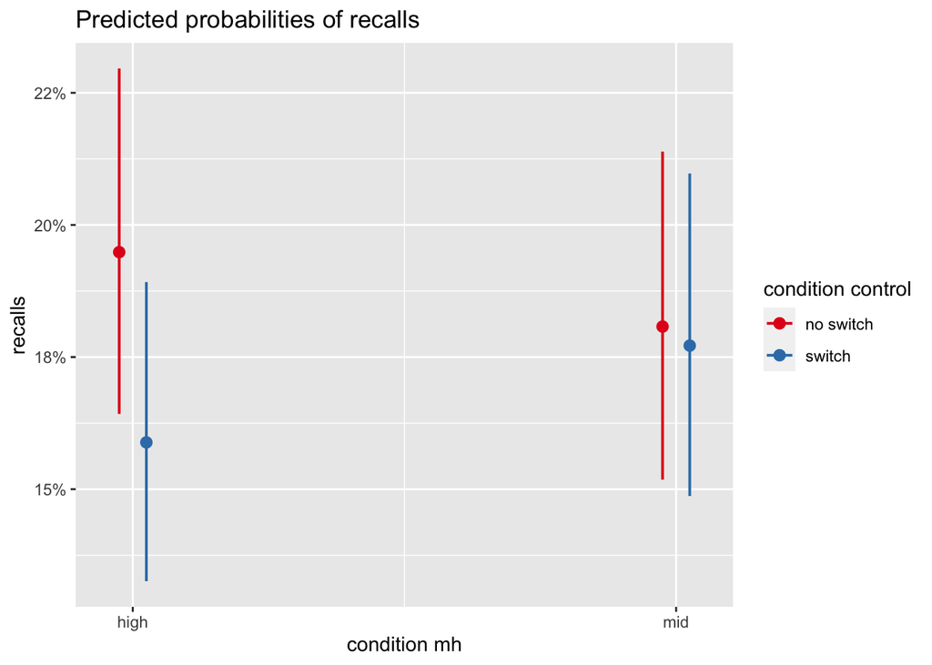

```r
plot_model(model_condition_novel_11_2, type = "int")
```

```r
r2glmm::r2beta(model_condition_novel_11_2, partial = TRUE)
```

```
##                                    Effect   Rsq upper.CL lower.CL
## 1                                   Model 0.004    0.008    0.002
## 4                    list_halfsecond_half 0.002    0.005    0.001
## 3                 condition_controlswitch 0.001    0.003    0.000
## 5                         blocknum_contin 0.001    0.003    0.000
## 6 condition_mhmid:condition_controlswitch 0.000    0.002    0.000
## 2                         condition_mhmid 0.000    0.001    0.000
```

```r
sf11_total_novel<- sf11_total_novel %>%
  mutate(condition = fct_relevel(condition, "high","cont_mid", "cont_high", "mid"))
sf11_total_novel_cond <- sf11_total_novel %>%
  filter(condition == "cont_high" | condition =="high")

model_condition_novel_11_3<- glmer(recalls~condition +list_half+blocknum_contin + (1|subject)+ (1|word_enc), family = binomial, data = sf11_total_novel_cond)
summary(model_condition_novel_11_3)
```

```
## Generalized linear mixed model fit by maximum likelihood (Laplace
##   Approximation) [glmerMod]
##  Family: binomial  ( logit )
## Formula: recalls ~ condition + list_half + blocknum_contin + (1 | subject) +
##     (1 | word_enc)
##    Data: sf11_total_novel_cond
##
##      AIC      BIC   logLik deviance df.resid
##   3999.8   4037.7  -1993.9   3987.8     4036
##
## Scaled residuals:
##     Min      1Q  Median      3Q     Max
## -1.0225 -0.5425 -0.4297 -0.2777  3.8559
##
## Random effects:
##  Groups   Name        Variance Std.Dev.
##  word_enc (Intercept) 0.02983  0.1727
##  subject  (Intercept) 0.34925  0.5910
## Number of obs: 4042, groups:  word_enc, 240; subject, 43
##
## Fixed effects:
##                      Estimate Std. Error z value             Pr(>|z|)
## (Intercept)          -1.65341    0.14703 -11.245 < 0.0000000000000002 ***
## conditioncont_high    0.25347    0.07977   3.177              0.00149 **
## list_halfsecond_half  0.32190    0.07983   4.032            0.0000552 ***
## blocknum_contin      -0.01799    0.01941  -0.927              0.35414
## ---
## Signif. codes:  0 '***' 0.001 '**' 0.01 '*' 0.05 '.' 0.1 ' ' 1
##
## Correlation of Fixed Effects:
##             (Intr) cndtn_ lst_h_
## cndtncnt_hg -0.293
## lst_hlfscn_ -0.301  0.027
## blcknm_cntn -0.599  0.002  0.005
```

```r
r2glmm::r2beta(model_condition_novel_11_3, partial = TRUE)
```

```
##                 Effect   Rsq upper.CL lower.CL
## 1                Model 0.006    0.013    0.003
## 3 list_halfsecond_half 0.004    0.009    0.001
## 2   conditioncont_high 0.002    0.006    0.000
## 4      blocknum_contin 0.000    0.002    0.000
```

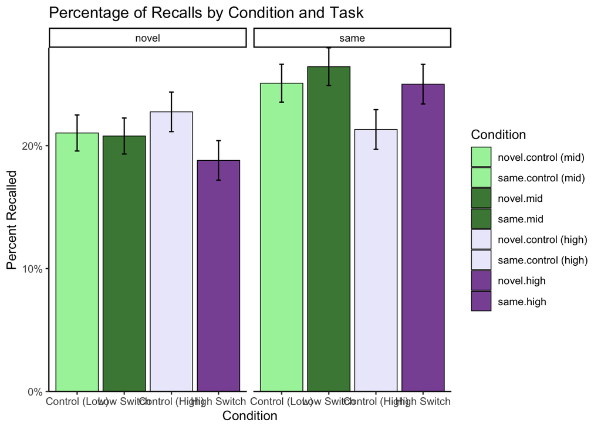

```r
same_immediate_df <- same_immediate_df %>%
  mutate(between_condition = "same")

novel_immediate_df <- novel_immediate_df %>%
  mutate(between_condition = "novel")


between_condition_bind_immed_full2 <- rbind(same_immediate_df, novel_immediate_df)


between_condition_bind_immed_full2 %>%
  ggplot(aes(x = condition, fill = interaction(between_condition,condition), y = mean)) +
  geom_bar(position="dodge", stat="identity", color = "black", linewidth = .3, alpha = .8) +
  labs(title    = "Percentage of Recalls by Condition and Task",
         x        = "Condition",
         y        = "Percent Recalled")+
  theme_classic()+
  geom_errorbar(width=.1, position=position_dodge(.9), aes(ymin=mean-standerr, ymax=mean +standerr))+
  scale_y_continuous(labels = scales::percent, expand = c(0,0))+
  scale_x_discrete(labels=c("control (mid)" = "Control (Low)","mid"= "Low Switch", "control (high)" = "Control (High)", "high" = "High Switch"))+
  scale_fill_manual(name = "Condition", values=c("lightgreen", "lightgreen", "darkgreen", "darkgreen", "lavender", "lavender","darkorchid4", "darkorchid4")) +
  facet_wrap(.~between_condition)
```

There was a signifcant three-way interaction, highlighting that the relationship between switch rate (high vs. low) and switch type (no-switch vs. switch) differed depending on whether scenes were repeating or novel.

```r
#these models used for paper

model_condition_total_11_2<- glmer(recalls~condition*between_condition +list_half+blocknum_contin + (1|subject)+ (1|word_enc), family = binomial, data = sf11_total_2)
summary(model_condition_total_11_2)
```

```
## Generalized linear mixed model fit by maximum likelihood (Laplace
##   Approximation) [glmerMod]
##  Family: binomial  ( logit )
## Formula:
## recalls ~ condition * between_condition + list_half + blocknum_contin +
##     (1 | subject) + (1 | word_enc)
##    Data: sf11_total_2
##
##      AIC      BIC   logLik deviance df.resid
##  16548.0  16640.1  -8262.0  16524.0    15968
##
## Scaled residuals:
##     Min      1Q  Median      3Q     Max
## -1.1808 -0.5663 -0.4592 -0.2963  4.6110
##
## Random effects:
##  Groups   Name        Variance Std.Dev.
##  word_enc (Intercept) 0.08458  0.2908
##  subject  (Intercept) 0.23887  0.4887
## Number of obs: 15980, groups:  word_enc, 240; subject, 84
##
## Fixed effects:
##                                          Estimate Std. Error z value
## (Intercept)                             -1.401051   0.104492 -13.408
## conditioncont_mid                       -0.097171   0.079086  -1.229
## conditionhigh                           -0.254817   0.079985  -3.186
## conditionmid                            -0.117159   0.078369  -1.495
## between_conditionsame                   -0.068634   0.133292  -0.515
## list_halfsecond_half                     0.307920   0.039000   7.895
## blocknum_contin                         -0.014924   0.008486  -1.759
## conditioncont_mid:between_conditionsame  0.321879   0.111394   2.890
## conditionhigh:between_conditionsame      0.464092   0.111555   4.160
## conditionmid:between_conditionsame       0.413050   0.109973   3.756
##                                                     Pr(>|z|)
## (Intercept)                             < 0.0000000000000002 ***
## conditioncont_mid                                   0.219195
## conditionhigh                                       0.001444 **
## conditionmid                                        0.134924
## between_conditionsame                               0.606612
## list_halfsecond_half                     0.00000000000000289 ***
## blocknum_contin                                     0.078619 .
## conditioncont_mid:between_conditionsame             0.003858 **
## conditionhigh:between_conditionsame      0.00003179626906907 ***
## conditionmid:between_conditionsame                  0.000173 ***
## ---
## Signif. codes:  0 '***' 0.001 '**' 0.01 '*' 0.05 '.' 0.1 ' ' 1
##
## Correlation of Fixed Effects:
##             (Intr) cndtn_ cndtnh cndtnm btwn_c lst_h_ blckn_ cnd_:_ cndtnh:_
## cndtncnt_md -0.373
## conditinhgh -0.363  0.484
## conditionmd -0.375  0.494  0.488
## btwn_cndtns -0.624  0.290  0.287  0.293
## lst_hlfscn_ -0.196  0.001 -0.011 -0.010  0.000
## blcknm_cntn -0.365  0.009 -0.001  0.011  0.003  0.002
## cndtncnt_:_  0.265 -0.710 -0.344 -0.352 -0.425  0.001 -0.008
## cndtnhgh:b_  0.261 -0.348 -0.717 -0.350 -0.423  0.003  0.000  0.507
## cndtnmd:bt_  0.268 -0.353 -0.348 -0.713 -0.430  0.003 -0.009  0.515  0.514
## optimizer (Nelder_Mead) convergence code: 0 (OK)
## Model failed to converge with max|grad| = 0.00439645 (tol = 0.002, component 1)
```

```r
sf11_total_2_high <- sf11_total_2 %>%
  filter(condition == "high" | condition == "cont_high")


model_condition_total_11_2_high<- glmer(recalls~condition*between_condition +list_half+blocknum_contin + (1|subject)+ (1|word_enc), family = binomial, data = sf11_total_2_high)
summary(model_condition_total_11_2_high)
```

```
## Generalized linear mixed model fit by maximum likelihood (Laplace
##   Approximation) [glmerMod]
##  Family: binomial  ( logit )
## Formula:
## recalls ~ condition * between_condition + list_half + blocknum_contin +
##     (1 | subject) + (1 | word_enc)
##    Data: sf11_total_2_high
##
##      AIC      BIC   logLik deviance df.resid
##   8155.9   8211.8  -4070.0   8139.9     7982
##
## Scaled residuals:
##     Min      1Q  Median      3Q     Max
## -1.1025 -0.5501 -0.4436 -0.3096  4.1942
##
## Random effects:
##  Groups   Name        Variance Std.Dev.
##  word_enc (Intercept) 0.08967  0.2994
##  subject  (Intercept) 0.26166  0.5115
## Number of obs: 7990, groups:  word_enc, 240; subject, 84
##
## Fixed effects:
##                                     Estimate Std. Error z value
## (Intercept)                         -1.42687    0.11927 -11.963
## conditionhigh                       -0.25915    0.08011  -3.235
## between_conditionsame               -0.06049    0.13772  -0.439
## list_halfsecond_half                 0.35275    0.05598   6.301
## blocknum_contin                     -0.01586    0.01337  -1.186
## conditionhigh:between_conditionsame  0.45830    0.11184   4.098
##                                                 Pr(>|z|)
## (Intercept)                         < 0.0000000000000002 ***
## conditionhigh                                    0.00122 **
## between_conditionsame                            0.66047
## list_halfsecond_half                      0.000000000296 ***
## blocknum_contin                                  0.23552
## conditionhigh:between_conditionsame       0.000041698008 ***
## ---
## Signif. codes:  0 '***' 0.001 '**' 0.01 '*' 0.05 '.' 0.1 ' ' 1
##
## Correlation of Fixed Effects:
##             (Intr) cndtnh btwn_c lst_h_ blckn_
## conditinhgh -0.313
## btwn_cndtns -0.567  0.278
## lst_hlfscn_ -0.250 -0.019  0.000
## blcknm_cntn -0.506 -0.002  0.006  0.002
## cndtnhgh:b_  0.227 -0.717 -0.411  0.006  0.000
```

```r
r2glmm::r2beta(model_condition_total_11_2_high, partial = TRUE)
```

```
##                                Effect   Rsq upper.CL lower.CL
## 1                               Model 0.008    0.013    0.005
## 4                list_halfsecond_half 0.005    0.008    0.002
## 6 conditionhigh:between_conditionsame 0.002    0.004    0.001
## 2                       conditionhigh 0.001    0.003    0.000
## 5                     blocknum_contin 0.000    0.001    0.000
## 3               between_conditionsame 0.000    0.001    0.000
```

```r
sf11_total_2<- sf11_total_2 %>%
  mutate(condition_mh = fct_relevel(condition_mh, "mid","high"))
model_condition_total_11_3<- glmer(recalls~condition_mh*condition_control*between_condition +list_half+blocknum_contin + (1|subject)+ (1|word_enc), family = binomial, data = sf11_total_2)
summary(model_condition_total_11_3)
```

```
## Generalized linear mixed model fit by maximum likelihood (Laplace
##   Approximation) [glmerMod]
##  Family: binomial  ( logit )
## Formula: recalls ~ condition_mh * condition_control * between_condition +
##     list_half + blocknum_contin + (1 | subject) + (1 | word_enc)
##    Data: sf11_total_2
##
##      AIC      BIC   logLik deviance df.resid
##  16548.0  16640.1  -8262.0  16524.0    15968
##
## Scaled residuals:
##     Min      1Q  Median      3Q     Max
## -1.1808 -0.5663 -0.4592 -0.2963  4.6104
##
## Random effects:
##  Groups   Name        Variance Std.Dev.
##  word_enc (Intercept) 0.08453  0.2907
##  subject  (Intercept) 0.23882  0.4887
## Number of obs: 15980, groups:  word_enc, 240; subject, 84
##
## Fixed effects:
##                                                                 Estimate
## (Intercept)                                                    -1.497963
## condition_mhhigh                                                0.097178
## condition_controlswitch                                        -0.019819
## between_conditionsame                                           0.252894
## list_halfsecond_half                                            0.307834
## blocknum_contin                                                -0.014940
## condition_mhhigh:condition_controlswitch                       -0.234920
## condition_mhhigh:between_conditionsame                         -0.321495
## condition_controlswitch:between_conditionsame                   0.091353
## condition_mhhigh:condition_controlswitch:between_conditionsame  0.372642
##                                                                Std. Error
## (Intercept)                                                      0.104920
## condition_mhhigh                                                 0.079095
## condition_controlswitch                                          0.079193
## between_conditionsame                                            0.132545
## list_halfsecond_half                                             0.039000
## blocknum_contin                                                  0.008486
## condition_mhhigh:condition_controlswitch                         0.112581
```

[output cut: 47 more lines]

```
## cndtn_mhhgh:b_  0.271 -0.711  -0.362  -0.413 -0.001  0.008  0.499
## cndtn_cnt:_     0.279 -0.370  -0.726  -0.422  0.002  0.000  0.511
## cndtn_m:_:_    -0.196  0.508   0.508   0.295  0.001  0.000 -0.722
##                cndtn_mhhgh:b_ cndtn_c:_
## cndtn_mhhgh
## cndtn_cntrl
## btwn_cndtns
## lst_hlfscn_
## blcknm_cntn
## cndtn_mhhgh:c_
## cndtn_mhhgh:b_
## cndtn_cnt:_     0.502
## cndtn_m:_:_    -0.714         -0.699
## optimizer (Nelder_Mead) convergence code: 0 (OK)
## Model failed to converge with max|grad| = 0.00637558 (tol = 0.002, component 1)
```

```r
r2glmm::r2beta(model_condition_total_11_3, partial = TRUE)
```

```
##                                                            Effect   Rsq
## 1                                                           Model 0.008
## 5                                            list_halfsecond_half 0.004
## 4                                           between_conditionsame 0.001
## 8                          condition_mhhigh:between_conditionsame 0.001
## 10 condition_mhhigh:condition_controlswitch:between_conditionsame 0.000
## 7                        condition_mhhigh:condition_controlswitch 0.000
## 6                                                 blocknum_contin 0.000
## 2                                                condition_mhhigh 0.000
## 9                   condition_controlswitch:between_conditionsame 0.000
## 3                                         condition_controlswitch 0.000
##    upper.CL lower.CL
## 1     0.011    0.006
## 5     0.006    0.002
## 4     0.002    0.000
## 8     0.001    0.000
## 10    0.001    0.000
## 7     0.001    0.000
## 6     0.001    0.000
## 2     0.001    0.000
## 9     0.000    0.000
## 3     0.000    0.000
```

```r
model_condition_total_11_4<- glmer(recalls~between_condition*condition_mh +list_half+blocknum_contin + (1|subject)+ (1|word_enc), family = binomial, data = sf11_total_2)
summary(model_condition_total_11_4)
```

```
## Generalized linear mixed model fit by maximum likelihood (Laplace
##   Approximation) [glmerMod]
##  Family: binomial  ( logit )
## Formula:
## recalls ~ between_condition * condition_mh + list_half + blocknum_contin +
##     (1 | subject) + (1 | word_enc)
##    Data: sf11_total_2
##
##      AIC      BIC   logLik deviance df.resid
##  16558.2  16619.6  -8271.1  16542.2    15972
##
## Scaled residuals:
##     Min      1Q  Median      3Q     Max
## -1.1633 -0.5665 -0.4610 -0.2984  4.3033
##
## Random effects:
##  Groups   Name        Variance Std.Dev.
##  word_enc (Intercept) 0.08351  0.2890
##  subject  (Intercept) 0.23827  0.4881
## Number of obs: 15980, groups:  word_enc, 240; subject, 84
##
## Fixed effects:
##                                         Estimate Std. Error z value
## (Intercept)                            -1.507715   0.096810 -15.574
## between_conditionsame                   0.299738   0.120045   2.497
## condition_mhhigh                       -0.018815   0.056217  -0.335
## list_halfsecond_half                    0.307927   0.038969   7.902
## blocknum_contin                        -0.014955   0.008481  -1.763
## between_conditionsame:condition_mhhigh -0.132934   0.077896  -1.707
##                                                    Pr(>|z|)
## (Intercept)                            < 0.0000000000000002 ***
## between_conditionsame                                0.0125 *
## condition_mhhigh                                     0.7379
## list_halfsecond_half                    0.00000000000000275 ***
## blocknum_contin                                      0.0778 .
## between_conditionsame:condition_mhhigh               0.0879 .
## ---
## Signif. codes:  0 '***' 0.001 '**' 0.01 '*' 0.05 '.' 0.1 ' ' 1
##
## Correlation of Fixed Effects:
##             (Intr) btwn_c cndtn_ lst_h_ blckn_
## btwn_cndtns -0.616
## cndtn_mhhgh -0.282  0.232
## lst_hlfscn_ -0.215  0.002 -0.002
## blcknm_cntn -0.386 -0.005 -0.014  0.001
## btwn_cndt:_  0.204 -0.318 -0.722 -0.001  0.012
```

```r
r2glmm::r2beta(model_condition_total_11_4, partial = TRUE)
```

```
##                                   Effect   Rsq upper.CL lower.CL
## 1                                  Model 0.007    0.009    0.004
## 4                   list_halfsecond_half 0.004    0.006    0.002
## 2                  between_conditionsame 0.002    0.003    0.001
## 5                        blocknum_contin 0.000    0.001    0.000
## 6 between_conditionsame:condition_mhhigh 0.000    0.001    0.000
## 3                       condition_mhhigh 0.000    0.000    0.000
```

```r
#model 2x2 mid/high and switch/repeat

sf11_total_3<-sf11_total_2 %>%
  filter(condition == "high" | condition == "mid") %>%
  filter(task_switch == "switch" | task_switch == "repeat")



#same

sf11_total_same_transition<-sf11_total_3 %>%
  filter(condition == "high" | condition == "mid") %>%
  filter(task_switch == "switch" | task_switch == "repeat") %>%
  filter(between_condition == "same")

model_transition_11_same<- glmer(recalls~condition*task_switch + list_half+(1|subject)+ (1|word_enc), family = binomial, data = sf11_total_same_transition)
summary(model_transition_11_same)
```

```
## Generalized linear mixed model fit by maximum likelihood (Laplace
##   Approximation) [glmerMod]
##  Family: binomial  ( logit )
## Formula: recalls ~ condition * task_switch + list_half + (1 | subject) +
##     (1 | word_enc)
##    Data: sf11_total_same_transition
##
##      AIC      BIC   logLik deviance df.resid
##   4287.7   4331.5  -2136.8   4273.7     3857
##
## Scaled residuals:
##     Min      1Q  Median      3Q     Max
## -1.1083 -0.5971 -0.4878  1.0012  3.1632
##
## Random effects:
##  Groups   Name        Variance Std.Dev.
##  word_enc (Intercept) 0.1674   0.4091
##  subject  (Intercept) 0.1578   0.3972
## Number of obs: 3864, groups:  word_enc, 240; subject, 41
##
## Fixed effects:
##                                Estimate Std. Error z value             Pr(>|z|)
## (Intercept)                    -1.43153    0.11110 -12.885 < 0.0000000000000002
## conditionmid                    0.04570    0.09777   0.467                0.640
## task_switchswitch               0.03869    0.10914   0.354                0.723
## list_halfsecond_half            0.45421    0.07777   5.840        0.00000000521
## conditionmid:task_switchswitch  0.08624    0.16864   0.511                0.609
##
## (Intercept)                    ***
## conditionmid
## task_switchswitch
## list_halfsecond_half           ***
## conditionmid:task_switchswitch
## ---
## Signif. codes:  0 '***' 0.001 '**' 0.01 '*' 0.05 '.' 0.1 ' ' 1
##
## Correlation of Fixed Effects:
##             (Intr) cndtnm tsk_sw lst_h_
## conditionmd -0.532
## tsk_swtchsw -0.465  0.541
## lst_hlfscn_ -0.391  0.003 -0.029
## cndtnmd:ts_  0.316 -0.579 -0.647 -0.026
```

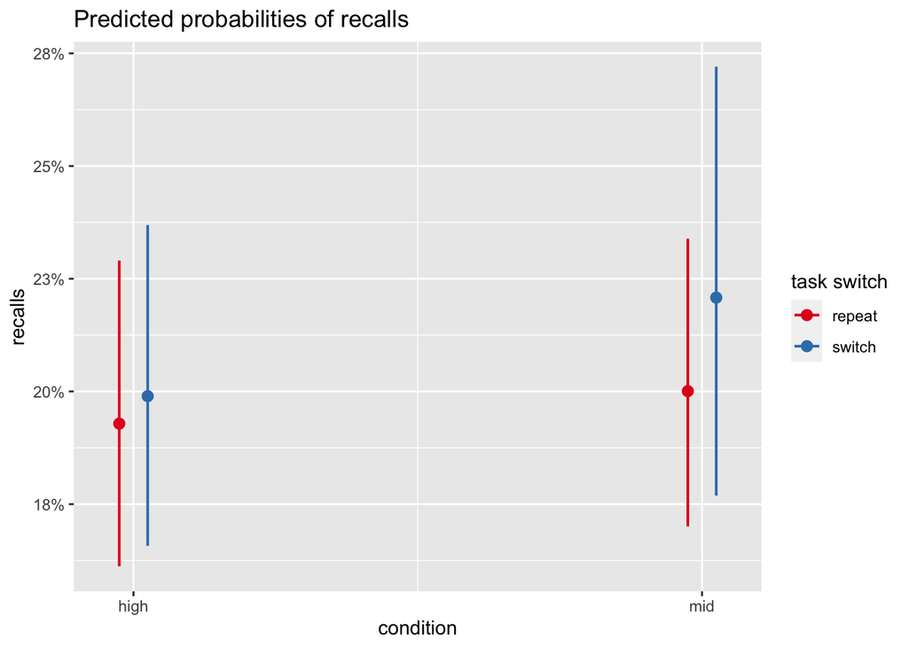

```r
plot_model(model_transition_11_same, type = "int")
```

```r
#novel

sf11_total_nov_transition<-sf11_total_3 %>%
  filter(condition == "high" | condition == "mid") %>%
  filter(task_switch == "switch" | task_switch == "repeat") %>%
  filter(between_condition == "novel")

model_transition_11_novel<- glmer(recalls~condition*task_switch +list_half + blocknum_contin + (1|subject)+ (1|word_enc), family = binomial, data = sf11_total_nov_transition)
```

```
## boundary (singular) fit: see help('isSingular')
```

```r
summary(model_transition_11_novel)
```

```
## Generalized linear mixed model fit by maximum likelihood (Laplace
##   Approximation) [glmerMod]
##  Family: binomial  ( logit )
## Formula: recalls ~ condition * task_switch + list_half + blocknum_contin +
##     (1 | subject) + (1 | word_enc)
##    Data: sf11_total_nov_transition
##
##      AIC      BIC   logLik deviance df.resid
##   3820.9   3871.2  -1902.5   3804.9     3948
##
## Scaled residuals:
##     Min      1Q  Median      3Q     Max
## -1.0510 -0.5182 -0.4292 -0.3114  4.1544
##
## Random effects:
##  Groups   Name        Variance Std.Dev.
##  word_enc (Intercept) 0.0000   0.0000
##  subject  (Intercept) 0.2817   0.5308
## Number of obs: 3956, groups:  word_enc, 240; subject, 43
##
## Fixed effects:
##                                Estimate Std. Error z value             Pr(>|z|)
## (Intercept)                    -1.50927    0.14567 -10.361 < 0.0000000000000002
## conditionmid                    0.15352    0.10384   1.478             0.139280
## task_switchswitch               0.02322    0.11756   0.198             0.843413
## list_halfsecond_half            0.41598    0.08312   5.005           0.00000056
## blocknum_contin                -0.06217    0.01796  -3.462             0.000536
## conditionmid:task_switchswitch -0.12785    0.18193  -0.703             0.482240
##
## (Intercept)                    ***
## conditionmid
## task_switchswitch
## list_halfsecond_half           ***
## blocknum_contin                ***
## conditionmid:task_switchswitch
## ---
## Signif. codes:  0 '***' 0.001 '**' 0.01 '*' 0.05 '.' 0.1 ' ' 1
##
## Correlation of Fixed Effects:
##             (Intr) cndtnm tsk_sw lst_h_ blckn_
## conditionmd -0.456
## tsk_swtchsw -0.383  0.548
## lst_hlfscn_ -0.275  0.003 -0.031
## blcknm_cntn -0.513  0.021  0.005 -0.085
## cndtnmd:ts_  0.257 -0.570 -0.645 -0.026  0.007
## optimizer (Nelder_Mead) convergence code: 0 (OK)
## boundary (singular) fit: see help('isSingular')
```

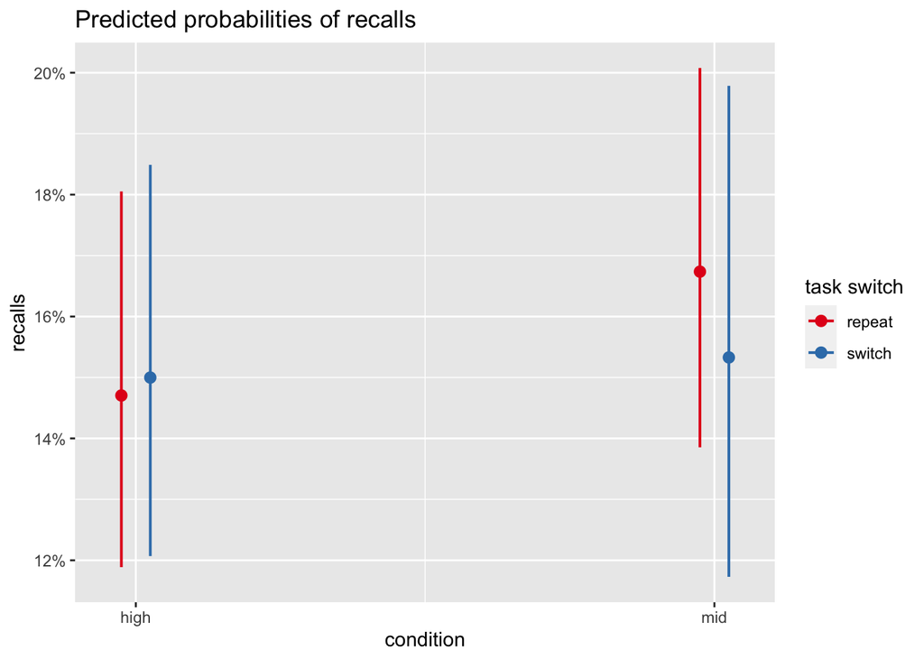

```r
plot_model(model_transition_11_novel, type = "int")
```

```r
#total

model_transition_11<- glmer(recalls~condition*task_switch*between_condition +list_half + blocknum_contin + (1|subject)+ (1|word_enc), family = binomial, data = sf11_total_3)
summary(model_transition_11)
```

```
## Generalized linear mixed model fit by maximum likelihood (Laplace
##   Approximation) [glmerMod]
##  Family: binomial  ( logit )
## Formula: recalls ~ condition * task_switch * between_condition + list_half +
##     blocknum_contin + (1 | subject) + (1 | word_enc)
##    Data: sf11_total_3
##
##      AIC      BIC   logLik deviance df.resid
##   8122.2   8205.8  -4049.1   8098.2     7808
##
## Scaled residuals:
##     Min      1Q  Median      3Q     Max
## -1.0816 -0.5679 -0.4596 -0.3099  4.1987
##
## Random effects:
##  Groups   Name        Variance Std.Dev.
##  word_enc (Intercept) 0.05057  0.2249
##  subject  (Intercept) 0.21777  0.4667
## Number of obs: 7820, groups:  word_enc, 240; subject, 84
##
## Fixed effects:
##                                                       Estimate Std. Error
## (Intercept)                                          -1.653640   0.126582
## conditionmid                                          0.156186   0.104043
## task_switchswitch                                     0.027832   0.117848
## between_conditionsame                                 0.398912   0.151316
## list_halfsecond_half                                  0.435641   0.056534
## blocknum_contin                                      -0.033517   0.012177
## conditionmid:task_switchswitch                       -0.131978   0.182297
## conditionmid:between_conditionsame                   -0.104923   0.141970
## task_switchswitch:between_conditionsame               0.006971   0.159740
## conditionmid:task_switchswitch:between_conditionsame  0.218211   0.246847
##                                                      z value
## (Intercept)                                          -13.064
## conditionmid                                           1.501
## task_switchswitch                                      0.236
## between_conditionsame                                  2.636
## list_halfsecond_half                                   7.706
## blocknum_contin                                       -2.753
## conditionmid:task_switchswitch                        -0.724
```

[output cut: 25 more lines]

```
## cndtnmd:bt_  0.380 -0.733 -0.402 -0.576  0.000 -0.013  0.418
## tsk_swtch:_  0.334 -0.405 -0.738 -0.512  0.000 -0.002  0.477      0.546
## cndtnmd:_:_ -0.216  0.421  0.477  0.331  0.002 -0.001 -0.738     -0.575
##             tsk_:_
## conditionmd
## tsk_swtchsw
## btwn_cndtns
## lst_hlfscn_
## blcknm_cntn
## cndtnmd:ts_
## cndtnmd:bt_
## tsk_swtch:_
## cndtnmd:_:_ -0.647
## optimizer (Nelder_Mead) convergence code: 0 (OK)
## Model failed to converge with max|grad| = 0.00328989 (tol = 0.002, component 1)
```

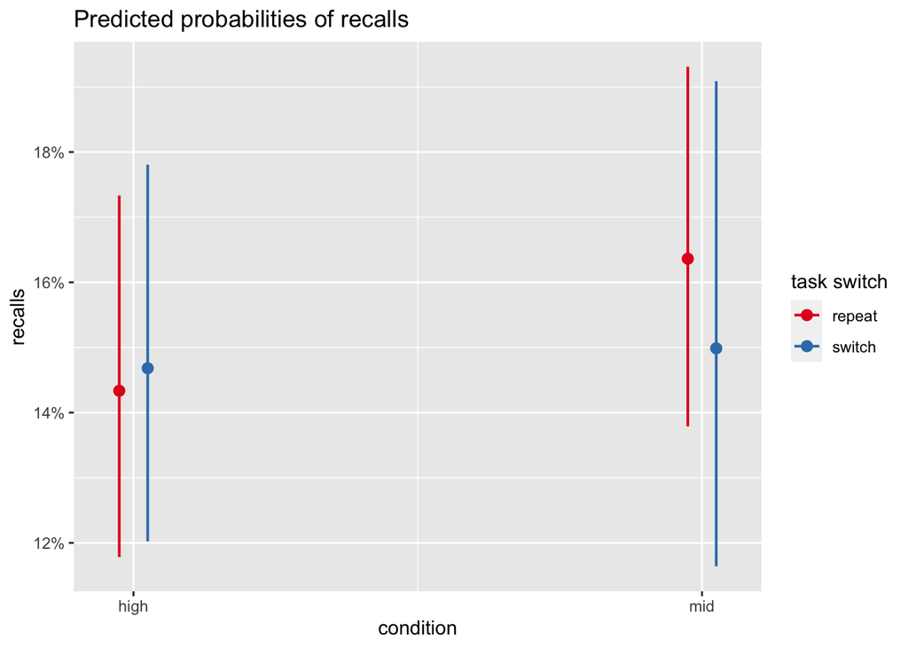

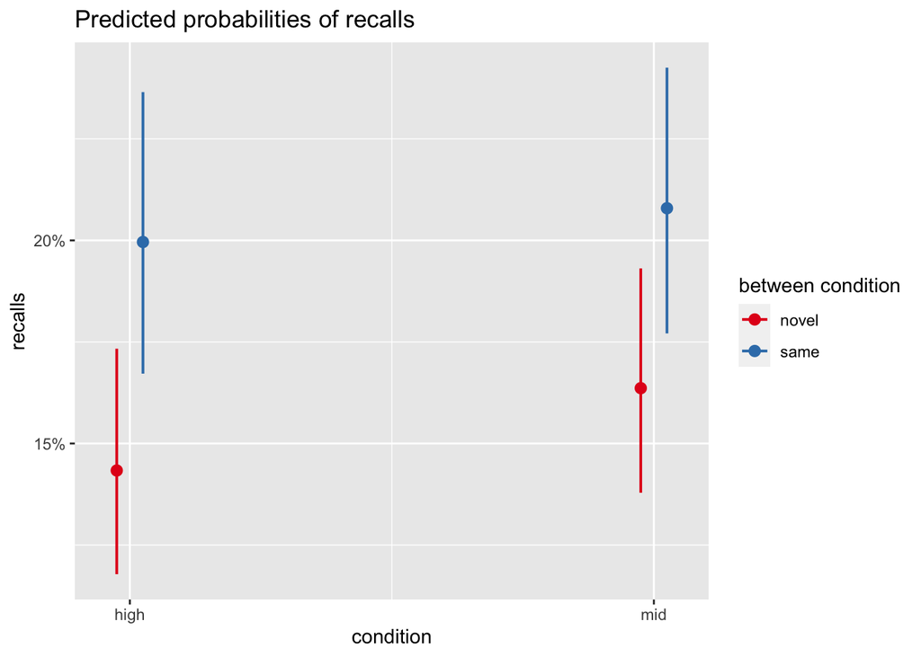

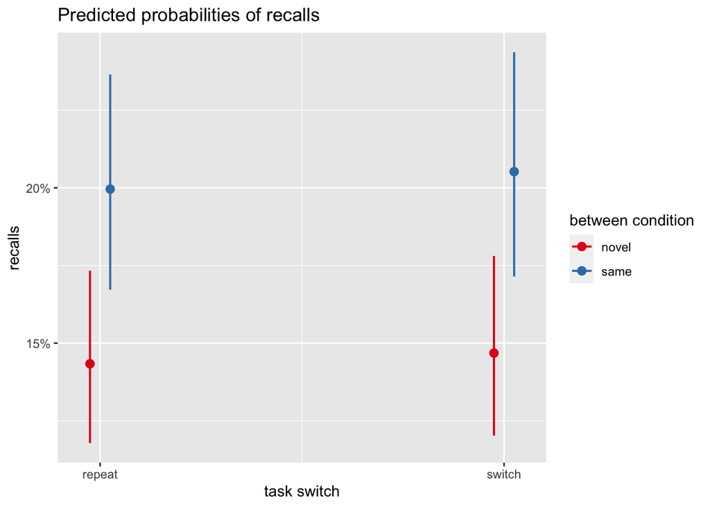

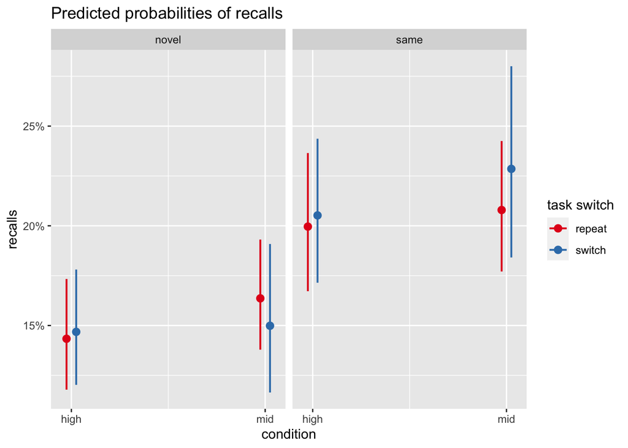

```r
plot_model(model_transition_11, type = "int")
```

```r
sf11_total_3_mid <- sf11_total_3 %>%
  filter(condition == "high") %>%
  filter(between_condition == "novel")


model_transition_11_mid<- glmer(recalls~task_switch +list_half + blocknum_contin + (1|subject)+ (1|word_enc), family = binomial, data = sf11_total_3_mid)
summary(model_transition_11_mid)
```

```
## Generalized linear mixed model fit by maximum likelihood (Laplace
##   Approximation) [glmerMod]
##  Family: binomial  ( logit )
## Formula: recalls ~ task_switch + list_half + blocknum_contin + (1 | subject) +
##     (1 | word_enc)
##    Data: sf11_total_3_mid
##
##      AIC      BIC   logLik deviance df.resid
##   1870.3   1903.8   -929.1   1858.3     1972
##
## Scaled residuals:
##     Min      1Q  Median      3Q     Max
## -0.9122 -0.4953 -0.4126 -0.3003  3.6121
##
## Random effects:
##  Groups   Name        Variance Std.Dev.
##  word_enc (Intercept) 0.06392  0.2528
##  subject  (Intercept) 0.32263  0.5680
## Number of obs: 1978, groups:  word_enc, 240; subject, 43
##
## Fixed effects:
##                      Estimate Std. Error z value             Pr(>|z|)
## (Intercept)          -1.73693    0.18943  -9.169 < 0.0000000000000002 ***
## task_switchswitch     0.02550    0.11845   0.215             0.829553
## list_halfsecond_half  0.45821    0.12051   3.802             0.000143 ***
## blocknum_contin      -0.02353    0.02862  -0.822             0.410965
## ---
## Signif. codes:  0 '***' 0.001 '**' 0.01 '*' 0.05 '.' 0.1 ' ' 1
##
## Correlation of Fixed Effects:
##             (Intr) tsk_sw lst_h_
## tsk_swtchsw -0.295
## lst_hlfscn_ -0.317 -0.042
## blcknm_cntn -0.653  0.005 -0.074
```

```r
#boundary vs preboundary- supplementary materials


sf11_total_mid_spc_3<- sf11_total_2 %>%
  filter(condition == "mid") %>%
  filter(trialnum == "5" | trialnum == "6" |trialnum == "8" |trialnum == "9" |trialnum == "10" |trialnum == "12"| trialnum == "13" |trialnum == "14"| trialnum == "16" |trialnum == "17" |trialnum == "18" |trialnum == "20") %>%
  mutate(trialnum_new = case_when(trialnum == "5" ~ "boundary",
                                  trialnum == "6" ~ "postboundary",
                               trialnum == "8" ~ "preboundary",
                               trialnum == "9" ~ "boundary",
                               trialnum == "10" ~ "postboundary",
                               trialnum == "12" ~ "preboundary",
                               trialnum == "13" ~ "boundary",
                               trialnum == "14" ~ "postboundary",
                               trialnum == "16" ~ "preboundary",
                               trialnum == "17" ~ "boundary",
                               trialnum == "18" ~ "postboundary",
                               trialnum == "20" ~ "preboundary"))



spc_mid_11_tally_immed2 <- sf11_total_mid_spc_3 %>%
  group_by(subject, trialnum_new) %>%
  tally()



spc_mid_11_immed2 <- sf11_total_mid_spc_3 %>%
  dplyr:: select(subject, trialnum_new, between_condition, recalls) %>%
  group_by(subject, trialnum_new, between_condition) %>%
  mutate(sum_recall2 = sum(recalls)) %>%
  summarise(mean_rec_cond = mean(sum_recall2))
merged_spc_immed <- merge(spc_mid_11_immed2,spc_mid_11_tally_immed2)


merged_spc_immed <- merged_spc_immed %>%
  mutate(prop_cond = mean_rec_cond/n)


merged_spc_immed<- merged_spc_immed %>%
  mutate(trialnum_new = fct_relevel(trialnum_new, "preboundary", "boundary", "postboundary"))


library(Rmisc)
spc_mid_11_immed <- summarySEwithin(merged_spc_immed, measurevar="prop_cond", withinvars = c("trialnum_new", "between_condition"),idvar = "subject", na.rm=FALSE, conf.interval=.95)
```

```
## Automatically converting the following non-factors to factors: between_condition
```

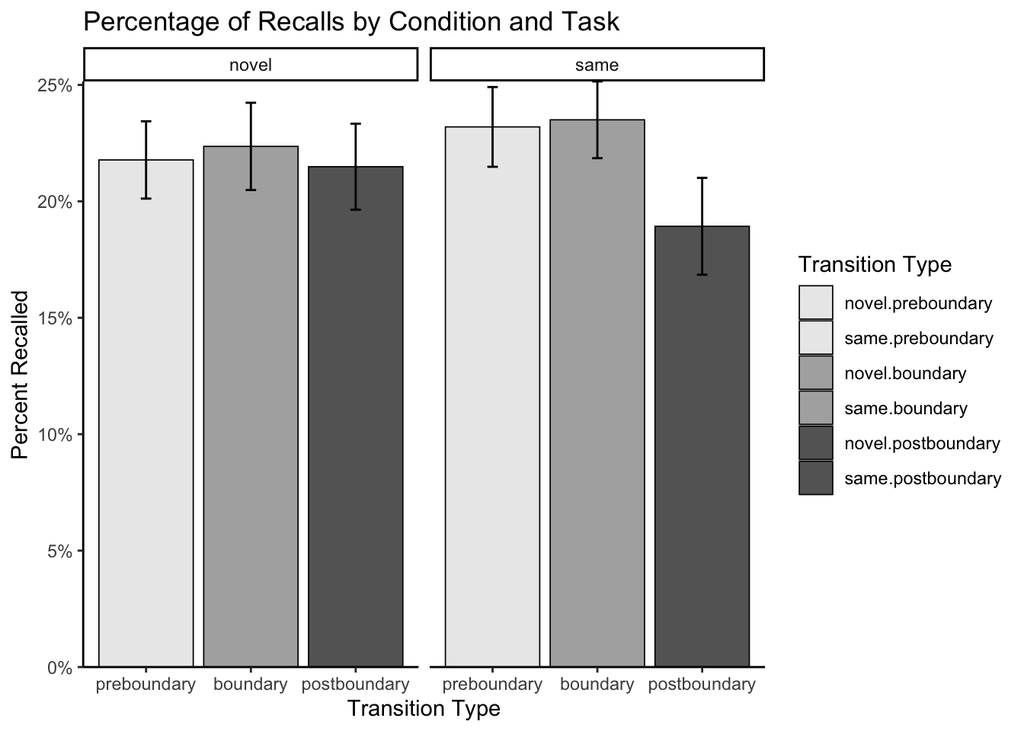

```r
spc_mid_11_immed %>%
  ggplot(aes(x = trialnum_new, fill = interaction(between_condition,trialnum_new), y = prop_cond)) +
  geom_bar(position="dodge", stat="identity", color = "black", linewidth = .3, alpha = .8) +
  labs(title    = "Percentage of Recalls by Condition and Task",
         x        = "Transition Type",
         y        = "Percent Recalled")+
  theme_classic()+
  geom_errorbar(width=.1, position=position_dodge(.9), aes(ymin=prop_cond-se, ymax=prop_cond+se))+
  scale_y_continuous(labels = scales::percent_format(accuracy = 1L), expand = c(0,0))+
  scale_fill_manual(name = "Transition Type", values=c("grey90", "grey90", "grey60", "grey60", "grey20", "grey20")) +
  facet_wrap(.~between_condition)
```

```r
#models for boundary vs preboundary
detach(package:Rmisc)
detach(package:plyr) #MUST RUN THIS

sf11_total_mid_spc_3<- sf11_total_mid_spc_3 %>%
  mutate(trialnum_new = fct_relevel(trialnum_new, "boundary", "preboundary", "postboundary"))
sf11_total_mid_spc_4 <- sf11_total_mid_spc_3 %>%
  filter(between_condition == "same")


sf11_total_mid_spc_3_model_total<- glmer(recalls~trialnum_new+ blocknum_contin + (1|subject)+ (1|word_enc), family = binomial, data = sf11_total_mid_spc_4)
summary(sf11_total_mid_spc_3_model_total)
```

```
## Generalized linear mixed model fit by maximum likelihood (Laplace
##   Approximation) [glmerMod]
##  Family: binomial  ( logit )
## Formula: recalls ~ trialnum_new + blocknum_contin + (1 | subject) + (1 |
##     word_enc)
##    Data: sf11_total_mid_spc_4
##
##      AIC      BIC   logLik deviance df.resid
##   1150.7   1180.2   -569.3   1138.7     1002
##
## Scaled residuals:
##     Min      1Q  Median      3Q     Max
## -0.6876 -0.5914 -0.5511  1.4636  1.9703
##
## Random effects:
##  Groups   Name        Variance Std.Dev.
##  word_enc (Intercept) 0.088218 0.29701
##  subject  (Intercept) 0.007745 0.08801
## Number of obs: 1008, groups:  word_enc, 234; subject, 41
##
## Fixed effects:
##                          Estimate Std. Error z value      Pr(>|z|)
## (Intercept)              -1.13642    0.19585  -5.802 0.00000000654 ***
## trialnum_newpreboundary   0.01423    0.17693   0.080         0.936
## trialnum_newpostboundary -0.24185    0.18263  -1.324         0.185
## blocknum_contin           0.02436    0.03186   0.765         0.445
## ---
## Signif. codes:  0 '***' 0.001 '**' 0.01 '*' 0.05 '.' 0.1 ' ' 1
##
## Correlation of Fixed Effects:
##             (Intr) trlnm_nwpr trlnm_nwps
## trlnm_nwprb -0.448
## trlnm_nwpst -0.435  0.486
## blcknm_cntn -0.743 -0.008     -0.006
```

```r
#confint(sf11_total_mid_spc_3_model_total)
```

```r
#prepare the data for temporal clustering by adding necessary columns to the recall dataframe

add_columns <- function(recall_df, enc_df) {
  selected_enc_df <- enc_df[, c("condition", "trialcode", "subject", "blocknum", "list_half", "task_switch","trialnum", "blockcode", "word_enc")]
  merged_df <- left_join(recall_df, selected_enc_df, by = c("V3" = "word_enc"))
  return(merged_df)
}

# Apply the function for each pair of recall and encoding data frames
merged_recall_list <- Map(add_columns, recall11_df_immed, sf11_by_sub)


# Identify the common columns across all data frames
common_columns <- Reduce(intersect, lapply(merged_recall_list, colnames))

# Ensure that each data frame in the list contains only the common columns
cleaned_recall_list <- lapply(merged_recall_list, function(df) df[, common_columns])

# Combine the cleaned data frames
recall11_df_immed2 <- do.call("rbind", cleaned_recall_list)
```

```r
#set up for temporal clustering for MATLAB
#encoding and retrieval for just blocks with mid in it
#Same

sf11_midblocks_same <- sf11_total_encodingonly_new %>%
  filter(blockcode == "control_mid_same" | blockcode == "mid_control_same")


sf10_mid_same <- split(sf11_midblocks_same,sf11_midblocks_same$subject)


encod_list_mid_same = list()
for (i in sf10_mid_same){
  encod_vert<- unstack(i, pool_number~blocknum)
  nrow <- max(sapply(encod_vert, length))
  encod_vert <- sapply(encod_vert, function(x) {
  length(x) <- 24
  x })
  encod_hor <- t(encod_vert) #transposes it
  encod_list_mid_same[[length(encod_list_mid_same)+1]] = encod_hor}


names(encod_list_mid_same)  <- paste("mid_enc_same_", c(137455 ,138853 ,139435 ,142837 ,146857 ,149335 ,149395 ,149437 ,150661 ,151921 ,152983 ,154801 ,156385 ,156541 ,156595 ,156691 ,156739 ,156751 ,156961 ,156979 ,157027 ,157057 ,157063 ,157069 ,157159 ,157171 ,157261 ,157327 ,157339 ,157381 ,157411 ,157435 ,157447 ,157471,157489, 157549, 157603, 157621, 157639, 157663, 157837), sep="")




library(MASS)
encode_list_same <- do.call(rbind, encod_list_mid_same)

write.matrix(encode_list_same, file="encode_list11_mid_same.csv")


#######################
#recall for mid, same

recall11_df_immed2_mid_same <- recall11_df_immed2 %>%
  filter(blockcode == "control_mid_same" | blockcode == "mid_control_same")


split_rec_mid11_same <- split(recall11_df_immed2_mid_same,recall11_df_immed2_mid_same$subject)



recall_list_mid_same = list()
for (i in split_rec_mid11_same){
  recall_vert<- unstack(i, V2~blocknum)
  recall_vert <- sapply(recall_vert, function(x) {
  length(x) <- 24
  x })
  recall_hor <- t(recall_vert) #transposes it
  recall_hor[is.na(recall_hor)] <- 0
  recall_list_mid_same[[length(recall_list_mid_same)+1]] = recall_hor}




names(recall_list_mid_same)  <- paste("mid_rec_",  c(137455 ,138853 ,139435 ,142837 ,146857 ,149335 ,149395 ,149437 ,150661 ,151921 ,152983 ,154801 ,156385 ,156541 ,156595 ,156691 ,156739 ,156751 ,156961 ,156979 ,157027 ,157057 ,157063 ,157069 ,157159 ,157171 ,157261 ,157327 ,157339 ,157381 ,157411 ,157435 ,157447 ,157471,157489, 157549, 157603, 157621, 157639, 157663, 157837), sep="")
recall_list_mid_same <- noquote(recall_list_mid_same)




recall_list <- do.call(rbind, recall_list_mid_same)




library(MASS)

write.matrix(recall_list, file="recall_list_11_mid_same2.csv")
```

```r
#temporal clustering for mid block
temp_clustering_mid_same <- c(0.6294,
    0.7248,
    0.6681,
    0.5629,
    0.5605,
    0.6591,
    0.6255,
    0.5138,
    0.6104,
    0.6461,
    0.5482,
    0.6185,
    0.5719,
    0.6613,
    0.5038,
    0.6138,
    0.4907,
    0.5577,
    0.5731,
    0.6366,
    0.6410,
    0.5782,
    0.6771,
    0.5283,
    0.4851,
    0.6201,
    0.5966,
    0.5560,
    0.7666,
    0.5604,
    0.5135,
    0.7081,
    0.6737,
    0.5219,
    0.6758,
    0.6701,
    0.5893,
    0.6938,
    0.5371,
    0.4529,
    0.5647)

mean(temp_clustering_mid_same, na.rm = TRUE)
```

```
## [1] 0.5996707
```

```r
sd(temp_clustering_mid_same, na.rm = TRUE)/ sqrt(length(temp_clustering_mid_same))
```

```
## [1] 0.01120388
```

```r
#set up for temporal clustering for MATLAB
#encoding and retrieval for just blocks with high in it
#Same

sf11_highblocks_same <- sf11_total_encodingonly_new %>%
  filter(blockcode == "control_high_same" | blockcode == "high_control_same")


sf10_high_same <- split(sf11_highblocks_same,sf11_highblocks_same$subject)


encod_list_high_same = list()
for (i in sf10_high_same){
  encod_vert<- unstack(i, pool_number~blocknum)
  nrow <- max(sapply(encod_vert, length))
  encod_vert <- sapply(encod_vert, function(x) {
  length(x) <- 24
  x })
  encod_hor <- t(encod_vert) #transposes it
  encod_list_high_same[[length(encod_list_high_same)+1]] = encod_hor}


names(encod_list_high_same)  <- paste("high_enc_same_", c(137455 ,138853 ,139435 ,142837 ,146857 ,149335 ,149395 ,149437 ,150661 ,151921 ,152983 ,154801 ,156385 ,156541 ,156595 ,156691 ,156739 ,156751 ,156961 ,156979 ,157027 ,157057 ,157063 ,157069 ,157159 ,157171 ,157261 ,157327 ,157339 ,157381 ,157411 ,157435 ,157447 ,157471,157489, 157549, 157603, 157621, 157639, 157663, 157837), sep="")



library(MASS)

encode_list_same <- do.call(rbind, encod_list_high_same)

write.matrix(encode_list_same, file="encode_list11_high_same.csv")


#######################
#recall for high, same

recall11_df_immed2_high_same <- recall11_df_immed2 %>%
  filter(blockcode == "control_high_same" | blockcode == "high_control_same")


split_rec_high11_same <- split(recall11_df_immed2_high_same,recall11_df_immed2_high_same$subject)



recall_list_high_same = list()
for (i in split_rec_high11_same){
  recall_vert<- unstack(i, V2~blocknum)
  recall_vert <- sapply(recall_vert, function(x) {
  length(x) <- 24
  x })
  recall_hor <- t(recall_vert) #transposes it
  recall_hor[is.na(recall_hor)] <- 0
  recall_list_high_same[[length(recall_list_high_same)+1]] = recall_hor}




names(recall_list_high_same)  <- paste("high_rec_",  c(137455 ,138853 ,139435 ,142837 ,146857 ,149335 ,149395 ,149437 ,150661 ,151921 ,152983 ,154801 ,156385 ,156541 ,156595 ,156691 ,156739 ,156751 ,156961 ,156979 ,157027 ,157057 ,157063 ,157069 ,157159 ,157171 ,157261 ,157327 ,157339 ,157381 ,157411 ,157435 ,157447 ,157471,157489, 157549, 157603, 157621, 157639, 157663, 157837), sep="")
recall_list_high_same <- noquote(recall_list_high_same)




recall_list <- do.call(rbind, recall_list_high_same)




library(MASS)

write.matrix(recall_list, file="recall_list_11_high_same2.csv")
```

```r
temp_clustering_high_same <- c(
    0.5913,
    0.5412,
    0.5424,
    0.5107,
    0.6055,
    0.4648,
    0.6156,
    0.6725,
    0.5659,
    0.5806,
    0.5839,
    0.6848,
    0.5282,
       NaN,
    0.5872,
    0.6386,
    0.6223,
    0.4080,
    0.5349,
    0.5391,
    0.5076,
    0.5799,
    0.6160,
    0.6603,
    0.4538,
    0.7401,
    0.5735,
    0.4770,
    0.4298,
    0.5097,
    0.5944,
    0.8118,
    0.5348,
    0.5236,
    0.4721,
    0.6364,
    0.5932,
    0.6683,
    0.5731,
    0.6140,
    0.5145)

mean(temp_clustering_high_same, na.rm = TRUE)
```

```
## [1] 0.572535
```

```r
sd(temp_clustering_high_same, na.rm = TRUE)/ sqrt(length(temp_clustering_high_same))
```

```
## [1] 0.01279952
```

```r
temp_clustering_same_v1 <- c(0.6294,
    0.7248,
    0.6681,
    0.5629,
    0.5605,
    0.6591,
    0.6255,
    0.5138,
    0.6104,
    0.6461,
    0.5482,
    0.6185,
    0.5719,
    0.6613,
    0.5038,
    0.6138,
    0.4907,
    0.5577,
    0.5731,
    0.6366,
    0.6410,
    0.5782,
    0.6771,
    0.5283,
    0.4851,
    0.6201,
    0.5966,
    0.5560,
    0.7666,
    0.5604,
    0.5135,
    0.7081,
    0.6737,
    0.5219,
    0.6758,
    0.6701,
    0.5893,
    0.6938,
    0.5371,
    0.4529,
    0.5647,
    0.5913,
    0.5412,
    0.5424,
    0.5107,
    0.6055,
    0.4648,
    0.6156,
    0.6725,
    0.5659,
    0.5806,
    0.5839,
    0.6848,
    0.5282,
       NaN,
    0.5872,
    0.6386,
    0.6223,
    0.4080,
    0.5349,
    0.5391,
    0.5076,
    0.5799,
    0.6160,
    0.6603,
    0.4538,
    0.7401,
    0.5735,
    0.4770,
    0.4298,
    0.5097,
    0.5944,
    0.8118,
    0.5348,
    0.5236,
    0.4721,
    0.6364,
    0.5932,
    0.6683,
    0.5731,
    0.6140,
    0.5145)


mean(temp_clustering_same_v1, na.rm = TRUE)
```

```
## [1] 0.5862704
```

```r
sd(temp_clustering_same_v1, na.rm = TRUE)/ sqrt(length(temp_clustering_same_v1))
```

```
## [1] 0.008578311
```

```r
#set up for temporal clustering for MATLAB
#encoding and retrieval for just blocks with mid in it
#novel

sf11_midblocks_novel <- sf11_total_encodingonly_new %>%
  filter(blockcode == "control_mid_novel" | blockcode == "mid_control_novel")


sf10_mid_novel <- split(sf11_midblocks_novel,sf11_midblocks_novel$subject)


encod_list_mid_novel = list()
for (i in sf10_mid_novel){
  encod_vert<- unstack(i, pool_number~blocknum)
  nrow <- max(sapply(encod_vert, length))
  encod_vert <- sapply(encod_vert, function(x) {
  length(x) <- 24
  x })
  encod_hor <- t(encod_vert) #transposes it
  encod_list_mid_novel[[length(encod_list_mid_novel)+1]] = encod_hor}


names(encod_list_mid_novel)  <- paste("mid_enc_novel_", c( 145912 ,148570, 149512, 151762,152818 ,153382 ,154174 ,154264 ,154348 ,154438 ,154444 ,154906 ,154984 ,155560 ,156130 ,156418 ,156436 ,156544 ,156550 ,156586 ,156604 ,156784 ,156970 ,156988 ,157000 ,157198 ,157210,157246 ,157270 ,157354 ,157432 ,157438 ,157456 ,157474 ,157486 ,157498 ,157648 ,157696 ,157912 ,158350 ,742243848 ,742243852 ,742243854), sep="")




library(MASS)

encode_list_novel <- do.call(rbind, encod_list_mid_novel)

write.matrix(encode_list_novel, file="encode_list11_mid_novel2.csv")


#######################
#recall for mid, novel

recall11_df_immed2_mid_novel <- recall11_df_immed2 %>%
  filter(blockcode == "control_mid_novel" | blockcode == "mid_control_novel")


split_rec_mid11_novel <- split(recall11_df_immed2_mid_novel,recall11_df_immed2_mid_novel$subject)



recall_list_mid_novel = list()
for (i in split_rec_mid11_novel){
  recall_vert<- unstack(i, V2~blocknum)
  recall_vert <- sapply(recall_vert, function(x) {
  length(x) <- 24
  x })
  recall_hor <- t(recall_vert) #transposes it
  recall_hor[is.na(recall_hor)] <- 0
  recall_list_mid_novel[[length(recall_list_mid_novel)+1]] = recall_hor}




names(recall_list_mid_novel)  <- paste("mid_rec_",  c( 145912 ,148570, 149512, 151762,152818 ,153382 ,154174 ,154264 ,154348 ,154438 ,154444 ,154906 ,154984 ,155560 ,156130 ,156418 ,156436 ,156544 ,156550 ,156586 ,156604 ,156784 ,156970 ,156988 ,157000 ,157198 ,157210,157246 ,157270 ,157354 ,157432 ,157438 ,157456 ,157474 ,157486 ,157498 ,157648 ,157696 ,157912 ,158350 ,742243848 ,742243852 ,742243854), sep="")
recall_list_mid_novel <- noquote(recall_list_mid_novel)


recall_list <- do.call(rbind, recall_list_mid_novel)




library(MASS)

write.matrix(recall_list, file="recall_list_11_mid_novel3.csv")
```

```r
temp_clustering_mid_novel <- c( 0.5586,
    0.7019,
    0.8088,
    0.9773,
    0.6331,
    0.6501,
    0.7295,
    0.6630,
    0.5439,
    0.6396,
    0.7151,
    0.7514,
    0.5306,
    0.7012,
    0.8864,
    0.6320,
    0.6272,
    0.5975,
    0.6163,
    0.6034,
    0.7672,
    0.5739,
    0.4773,
    0.7610,
    0.6844,
    0.5185,
    0.6524,
    0.6253,
    0.6223,
    0.5211,
    0.5104,
    0.5902,
    0.7207,
    0.5080,
    0.6682,
    0.6447,
    0.5158,
    0.5585,
    0.6618,
    0.6323,
    0.6088,
    0.4299,
    0.6889)


mean(temp_clustering_mid_novel, na.rm = TRUE)
```

```
## [1] 0.6397326
```

```r
sd(temp_clustering_mid_novel, na.rm = TRUE)/ sqrt(length(temp_clustering_mid_novel))
```

```
## [1] 0.0162417
```

```r
#set up for temporal clustering for MATLAB
#encoding and retrieval for just blocks with high in it
#novel

sf11_highblocks_novel <- sf11_total_encodingonly_new %>%
  filter(blockcode == "control_high_novel" | blockcode == "high_control_novel")


sf10_high_novel <- split(sf11_highblocks_novel,sf11_highblocks_novel$subject)


encod_list_high_novel = list()
for (i in sf10_high_novel){
  encod_vert<- unstack(i, pool_number~blocknum)
  nrow <- max(sapply(encod_vert, length))
  encod_vert <- sapply(encod_vert, function(x) {
  length(x) <- 24
  x })
  encod_hor <- t(encod_vert) #transposes it
  encod_list_high_novel[[length(encod_list_high_novel)+1]] = encod_hor}


names(encod_list_high_novel)  <- paste("high_enc_novel_", c( 145912 ,148570, 149512, 151762,152818 ,153382 ,154174 ,154264 ,154348 ,154438 ,154444 ,154906 ,154984 ,155560 ,156130 ,156418 ,156436 ,156544 ,156550 ,156586 ,156604 ,156784 ,156970 ,156988 ,157000 ,157198 ,157210,157246 ,157270 ,157354 ,157432 ,157438 ,157456 ,157474 ,157486 ,157498 ,157648 ,157696 ,157912 ,158350 ,742243848 ,742243852 ,742243854), sep="")





library(MASS)

encode_list_novel <- do.call(rbind, encod_list_high_novel)

write.matrix(encode_list_novel, file="encode_list11_high_novel_2.csv")


#######################
#recall for high, novel

recall11_df_immed2_high_novel <- recall11_df_immed2 %>%
  filter(blockcode == "control_high_novel" | blockcode == "high_control_novel")


split_rec_high11_novel <- split(recall11_df_immed2_high_novel,recall11_df_immed2_high_novel$subject)



recall_list_high_novel = list()
for (i in split_rec_high11_novel){
  recall_vert<- unstack(i, V2~blocknum)
  recall_vert <- sapply(recall_vert, function(x) {
  length(x) <- 24
  x })
  recall_hor <- t(recall_vert) #transposes it
  recall_hor[is.na(recall_hor)] <- 0
  recall_list_high_novel[[length(recall_list_high_novel)+1]] = recall_hor}




names(recall_list_high_novel)  <- paste("high_rec_",  c(145912 ,148570, 149512, 151762,152818 ,153382 ,154174 ,154264 ,154348 ,154438 ,154444 ,154906 ,154984 ,155560 ,156130 ,156418 ,156436 ,156544 ,156550 ,156604 ,156784 ,156970 ,156988 ,157000 ,157198 ,157210,157246 ,157270 ,157354 ,157432 ,157438 ,157456 ,157474 ,157486 ,157498 ,157648 ,157696 ,157912 ,158350 ,742243848 ,742243852 ,742243854), sep="")
recall_list_high_novel <- noquote(recall_list_high_novel)


recall_list <- do.call(rbind, recall_list_high_novel)


library(MASS)

write.matrix(recall_list, file="recall_list_11_high_novel_2.csv")
```

```r
temp_clustering_high_novel <- c(0.6218,
    0.7580,
    0.5822,
    0.6135,
    0.6605,
    0.6508,
    0.6780,
    0.6798,
    0.7765,
    0.6772,
    0.6140,
    0.6477,
    0.7175,
    0.6614,
    0.8262,
    0.6946,
    0.7339,
    0.4915,
    0.6327,
       NaN,
    0.7997,
    0.7396,
    0.7655,
    0.7857,
    0.6811,
    0.5203,
    0.6447,
    0.6798,
    0.7461,
    0.5364,
    0.7273,
    0.7668,
    0.5689,
    0.6760,
    0.7706,
    0.7299,
    0.5301,
    0.6069,
    0.7443,
    0.5735,
    0.4268,
    0.6687,
    0.8033)

mean(temp_clustering_high_novel, na.rm = TRUE)
```

```
## [1] 0.6716619
```

```r
sd(temp_clustering_high_novel, na.rm = TRUE)/ sqrt(length(temp_clustering_high_novel))
```

```
## [1] 0.01397214
```

```r
temp_clustering_novel_v1 <- c( 0.5586,
    0.7019,
    0.8088,
    0.9773,
    0.6331,
    0.6501,
    0.7295,
    0.6630,
    0.5439,
    0.6396,
    0.7151,
    0.7514,
    0.5306,
    0.7012,
    0.8864,
    0.6320,
    0.6272,
    0.5975,
    0.6163,
    0.6034,
    0.7672,
    0.5739,
    0.4773,
    0.7610,
    0.6844,
    0.5185,
    0.6524,
    0.6253,
    0.6223,
    0.5211,
    0.5104,
    0.5902,
    0.7207,
    0.5080,
    0.6682,
    0.6447,
    0.5158,
    0.5585,
    0.6618,
    0.6323,
    0.6088,
    0.4299,
    0.6889,
    0.6218,
    0.7580,
    0.5822,
    0.6135,
    0.6605,
    0.6508,
    0.6780,
    0.6798,
    0.7765,
    0.6772,
    0.6140,
    0.6477,
    0.7175,
    0.6614,
    0.8262,
    0.6946,
    0.7339,
    0.4915,
    0.6327,
       NaN,
    0.7997,
    0.7396,
    0.7655,
    0.7857,
    0.6811,
    0.5203,
    0.6447,
    0.6798,
    0.7461,
    0.5364,
    0.7273,
    0.7668,
    0.5689,
    0.6760,
    0.7706,
    0.7299,
    0.5301,
    0.6069,
    0.7443,
    0.5735,
    0.4268,
    0.6687,
    0.8033)


mean(temp_clustering_novel_v1, na.rm = TRUE)
```

```
## [1] 0.6555094
```

```r
sd(temp_clustering_novel_v1, na.rm = TRUE)/ sqrt(length(temp_clustering_novel_v1))
```

```
## [1] 0.01079768
```

```r
length(temp_clustering_novel_v1)
```

```
## [1] 86
```

```r
#greater than chance-level clust

t.test(temp_clustering_high_novel, mu = .5)
```

```
##
##  One Sample t-test
##
## data:  temp_clustering_high_novel
## t = 12.142, df = 41, p-value = 0.00000000000000367
## alternative hypothesis: true mean is not equal to 0.5
## 95 percent confidence interval:
##  0.6431107 0.7002132
## sample estimates:
## mean of x
## 0.6716619
```

```r
t.test(temp_clustering_high_same, mu = .5)
```

```
##
##  One Sample t-test
##
## data:  temp_clustering_high_same
## t = 5.5975, df = 39, p-value = 0.000001876
## alternative hypothesis: true mean is not equal to 0.5
## 95 percent confidence interval:
##  0.5463239 0.5987461
## sample estimates:
## mean of x
##  0.572535
```

```r
t.test(temp_clustering_mid_novel, mu = .5)
```

```
##
##  One Sample t-test
##
## data:  temp_clustering_mid_novel
## t = 8.6033, df = 42, p-value = 0.00000000008188
## alternative hypothesis: true mean is not equal to 0.5
## 95 percent confidence interval:
##  0.6069555 0.6725096
## sample estimates:
## mean of x
## 0.6397326
```

```r
t.test(temp_clustering_mid_same, mu = .5)
```

```
##
##  One Sample t-test
##
## data:  temp_clustering_mid_same
## t = 8.8961, df = 40, p-value = 0.00000000005035
## alternative hypothesis: true mean is not equal to 0.5
## 95 percent confidence interval:
##  0.5770268 0.6223146
## sample estimates:
## mean of x
## 0.5996707
```

```r
#compare

t.test(temp_clustering_high_novel, temp_clustering_high_same)
```

```
##
##  Welch Two Sample t-test
##
## data:  temp_clustering_high_novel and temp_clustering_high_same
## t = 5.1688, df = 79.695, p-value = 0.000001707
## alternative hypothesis: true difference in means is not equal to 0
## 95 percent confidence interval:
##  0.06095941 0.13729440
## sample estimates:
## mean of x mean of y
## 0.6716619 0.5725350
```

```r
#participants recalled more items in order during the high condition in the novel condition than in the high condition in the switch back condition


t.test(temp_clustering_mid_novel, temp_clustering_mid_same)
```

```
##
##  Welch Two Sample t-test
##
## data:  temp_clustering_mid_novel and temp_clustering_mid_same
## t = 2.0304, df = 73.909, p-value = 0.04592
## alternative hypothesis: true difference in means is not equal to 0
## 95 percent confidence interval:
##  0.0007457734 0.0793778795
## sample estimates:
## mean of x mean of y
## 0.6397326 0.5996707
```

```r
#participants recalled more items in order during the mid condition in the novel condition than in the mid condition in the switch back condition


t.test(temp_clustering_high_same, temp_clustering_mid_same)
```

```
##
##  Welch Two Sample t-test
##
## data:  temp_clustering_high_same and temp_clustering_mid_same
## t = -1.5841, df = 77.096, p-value = 0.1173
## alternative hypothesis: true difference in means is not equal to 0
## 95 percent confidence interval:
##  -0.061246021  0.006974557
## sample estimates:
## mean of x mean of y
## 0.5725350 0.5996707
```

```r
t.test(temp_clustering_mid_novel, temp_clustering_high_novel)
```

```
##
##  Welch Two Sample t-test
##
## data:  temp_clustering_mid_novel and temp_clustering_high_novel
## t = -1.4828, df = 81.706, p-value = 0.142
## alternative hypothesis: true difference in means is not equal to 0
## 95 percent confidence interval:
##  -0.07476726  0.01090857
## sample estimates:
## mean of x mean of y
## 0.6397326 0.6716619
```

```r
t.test(temp_clustering_novel_v1, temp_clustering_same_v1)
```

```
##
##  Welch Two Sample t-test
##
## data:  temp_clustering_novel_v1 and temp_clustering_same_v1
## t = 4.991, df = 157.6, p-value = 0.000001575
## alternative hypothesis: true difference in means is not equal to 0
## 95 percent confidence interval:
##  0.04183825 0.09663984
## sample estimates:
## mean of x mean of y
## 0.6555094 0.5862704
```

```r
cd_df_novel <- data.frame(between_condition = rep("novel",times = 86),
                    temp_score = temp_clustering_novel_v1)


cd_df_same <- data.frame(between_condition = rep("same",times = 82),
                    temp_score = temp_clustering_same_v1)


cd_df_both<- rbind(cd_df_same, cd_df_novel)

cohensD(temp_score~between_condition, cd_df_both)
```

```
## [1] 0.7703154
```

Both switch rates across both levels of familiarity showed significant binding of items to their temporal context, as measured by greater than chance-level temporal clustering. However, when individuals were switching to novel versus repeated contexts, there was a greater reliance on temporal information (i.e., higher temporal clustering)

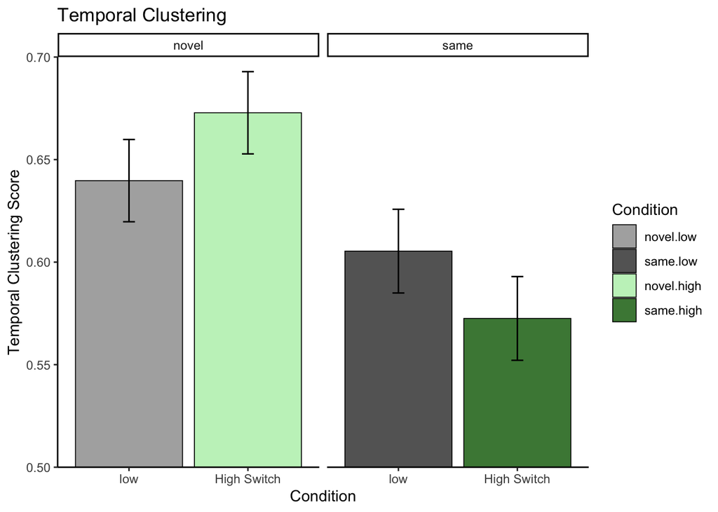

```r
#plot temporal clustering
#difference score error bars novel

temp_clust_11v1 <- import("temp_clustering_sf11_v1.csv")



temp_clust_11v1_2 <- temp_clust_11v1 %>%
  group_by(condition, between_condition, subject) %>%
  summarise(mean_temp_clust = mean(temp_clust_score))
difference_error_temp_clust <- temp_clust_11v1 %>%
  unite(condition2, condition:between_condition, remove = FALSE) %>%
  dplyr::select(subject, condition2, temp_clust_score) %>%
  reshape(idvar = "subject", timevar = "condition2", direction = "wide") %>%
  group_by(subject) %>%
  mutate(diff_same = sum(temp_clust_score.low_same- temp_clust_score.high_same)) %>%
  mutate(diff_novel = sum(temp_clust_score.low_novel- temp_clust_score.high_novel))



se_cont_temp_same <- std.error(difference_error_temp_clust$diff_same)

se_cont_temp_nov <- std.error(difference_error_temp_clust$diff_novel)


temp_clust_within_df = data.frame(condition = c("low", "high","low","high"),between_condition = c("same", "same", "novel", "novel"), mean = c(0.6053634, 0.5725350, 0.6397326, 0.6728310), standerr = c(0.02040952, 0.02040952, 0.0200526, 0.0200526))

temp_clust_within_df<- temp_clust_within_df %>%
  mutate(condition = fct_relevel(condition, "low", "high" ))

temp_clust_within_df %>%
  ggplot(aes(x = condition, fill = interaction(between_condition,condition), y = mean)) +
  geom_bar(position="dodge", stat="identity", color = "black", linewidth = .3, alpha = .8) +
  labs(title    = "Temporal Clustering",
         x        = "Condition",
         y        = "Temporal Clustering Score")+
  theme_classic()+
  geom_errorbar(width=.1, position=position_dodge(.9), aes(ymin=mean-standerr, ymax=mean+standerr))+
  scale_y_continuous(expand = c(0,0))+
  scale_x_discrete(labels=c("cont_mid" = "Control (Low)","mid"= "Low Switch", "cont_high" = "Control (High)", "high" = "High Switch"))+
  scale_fill_manual(name = "Condition", values=c("grey60", "grey20", "darkseagreen2", "darkgreen", "grey60", "grey20","lavender", "darkorchid4")) +
  facet_wrap(.~between_condition)+
  coord_cartesian(ylim = c(.5, .7))
```

```r
#model
model_temp_cluster<- lmer(temp_clust_score~condition*between_condition+ (1|subject),  data = temp_clust_11v1)
summary(model_temp_cluster)
```

```
## Linear mixed model fit by REML. t-tests use Satterthwaite's method [
## lmerModLmerTest]
## Formula: temp_clust_score ~ condition * between_condition + (1 | subject)
##    Data: temp_clust_11v1
##
## REML criterion at convergence: -293.2
##
## Scaled residuals:
##     Min      1Q  Median      3Q     Max
## -2.5531 -0.5986  0.0314  0.6143  4.1962
##
## Random effects:
##  Groups   Name        Variance  Std.Dev.
##  subject  (Intercept) 0.0004369 0.02090
##  Residual             0.0083160 0.09119
## Number of obs: 166, groups:  subject, 84
##
## Fixed effects:
##                                     Estimate Std. Error        df t value
## (Intercept)                          0.67279    0.01444 161.64521  46.606
## conditionlow                        -0.03306    0.01979  82.14331  -1.670
## between_conditionsame               -0.10018    0.02067 161.64609  -4.847
## conditionlow:between_conditionsame   0.06581    0.02833  82.16759   2.323
##                                                Pr(>|t|)
## (Intercept)                        < 0.0000000000000002 ***
## conditionlow                                     0.0987 .
## between_conditionsame                        0.00000292 ***
## conditionlow:between_conditionsame               0.0226 *
## ---
## Signif. codes:  0 '***' 0.001 '**' 0.01 '*' 0.05 '.' 0.1 ' ' 1
##
## Correlation of Fixed Effects:
##             (Intr) cndtnl btwn_c
## conditionlw -0.694
## btwn_cndtns -0.698  0.485
## cndtnlw:bt_  0.485 -0.699 -0.694
```

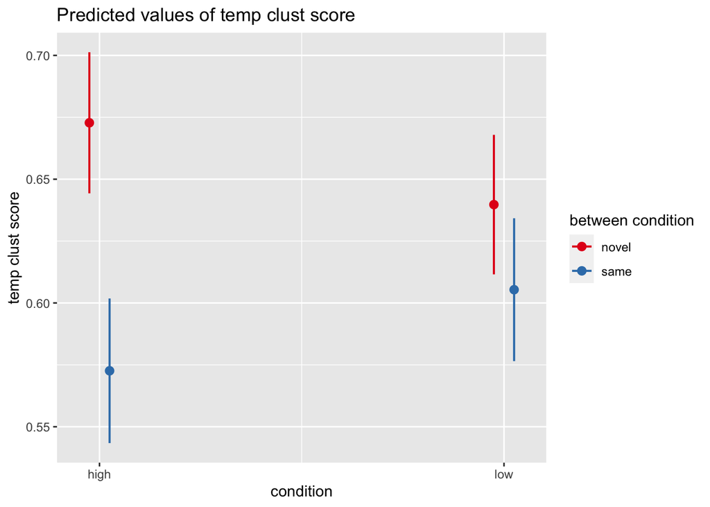

```r
plot_model(model_temp_cluster, type = "int")
```

#FINAL RECALL

```r
#most important code chunk

split_enc_11 <- split(sf11_total_encodingonly_between,sf11_total_encodingonly_between$subject)

#list of all subjects individual recall data
recall11_df = list(recall_data_final_137455,recall_data_final_138853, recall_data_final_139435, recall_data_final_142837, recall_data_final_145912, recall_data_final_146857, recall_data_final_148570, recall_data_final_149335, recall_data_final_149395, recall_data_final_149437, recall_data_final_149512, recall_data_final_150661, recall_data_final_151762, recall_data_final_151921, recall_data_final_152983, recall_data_final_153382, recall_data_final_154174, recall_data_final_154264, recall_data_final_154348, recall_data_final_154444, recall_data_final_154801, recall_data_final_154906, recall_data_final_154984, recall_data_final_155560, recall_data_final_156130, recall_data_final_156385, recall_data_final_156418, recall_data_final_156436, recall_data_final_156541, recall_data_final_156544, recall_data_final_156550, recall_data_final_156586, recall_data_final_156595, recall_data_final_156604, recall_data_final_156691, recall_data_final_156739, recall_data_final_156751, recall_data_final_156784, recall_data_final_156961, recall_data_final_156970, recall_data_final_156979, recall_data_final_156988, recall_data_final_157000, recall_data_final_157027, recall_data_final_157057, recall_data_final_157063, recall_data_final_157069, recall_data_final_157159, recall_data_final_157171, recall_data_final_157198, recall_data_final_157210, recall_data_final_157261, recall_data_final_157270, recall_data_final_157327, recall_data_final_157339, recall_data_final_157354,recall_data_final_157381, recall_data_final_157411, recall_data_final_157432, recall_data_final_157435, recall_data_final_157438, recall_data_final_157447, recall_data_final_157456, recall_data_final_157471, recall_data_final_157474, recall_data_final_157486, recall_data_final_157489, recall_data_final_157498, recall_data_final_157549, recall_data_final_157603, recall_data_final_157621, recall_data_final_157621, recall_data_final_157639, recall_data_final_157648, recall_data_final_157663, recall_data_final_157696, recall_data_final_157837, recall_data_final_157912, recall_data_final_158350, recall_data_final_742243848, recall_data_final_742243852, recall_data_final_742243854, recall_data_final_154438, recall_data_final_157246, recall_data_final_152818)



#list of task data
sf11_by_sub <- list(split_enc_11$'137455',split_enc_11$'138853', split_enc_11$'139435', split_enc_11$'142837', split_enc_11$'145912', split_enc_11$'146857', split_enc_11$'148570', split_enc_11$'149335', split_enc_11$'149395', split_enc_11$'149437', split_enc_11$'149512', split_enc_11$'150661', split_enc_11$'151762', split_enc_11$'151921', split_enc_11$'152983', split_enc_11$'153382', split_enc_11$'154174', split_enc_11$'154264', split_enc_11$'154348', split_enc_11$'154444', split_enc_11$'154801', split_enc_11$'154906', split_enc_11$'154984', split_enc_11$'155560', split_enc_11$'156130', split_enc_11$'156385', split_enc_11$'156418', split_enc_11$'156436', split_enc_11$'156541', split_enc_11$'156544', split_enc_11$'156550', split_enc_11$'156586', split_enc_11$'156595', split_enc_11$'156604', split_enc_11$'156691', split_enc_11$'156739', split_enc_11$'156751', split_enc_11$'156784', split_enc_11$'156961', split_enc_11$'156970', split_enc_11$'156979', split_enc_11$'156988', split_enc_11$'157000', split_enc_11$'157027', split_enc_11$'157057', split_enc_11$'157063', split_enc_11$'157069', split_enc_11$'157159', split_enc_11$'157171', split_enc_11$'157198', split_enc_11$'157210', split_enc_11$'157261', split_enc_11$'157270', split_enc_11$'157327', split_enc_11$'157339', split_enc_11$'157354',split_enc_11$'157381', split_enc_11$'157411', split_enc_11$'157432', split_enc_11$'157435', split_enc_11$'157438', split_enc_11$'157447', split_enc_11$'157456', split_enc_11$'157471', split_enc_11$'157474', split_enc_11$'157486', split_enc_11$'157489', split_enc_11$'157498', split_enc_11$'157549', split_enc_11$'157603', split_enc_11$'157621', split_enc_11$'157621', split_enc_11$'157639', split_enc_11$'157648', split_enc_11$'157663', split_enc_11$'157696', split_enc_11$'157837', split_enc_11$'157912', split_enc_11$'158350', split_enc_11$'742243848', split_enc_11$'742243852', split_enc_11$'742243854', split_enc_11$'154438', split_enc_11$'157246', split_enc_11$'152818')


#for every subject:
c = 0
for (ssid in array(1:length(recall11_df))){
    i = sf11_by_sub[[ssid]]
    j = recall11_df[[ssid]]
    c = c +1
    output  <- i %>%
      mutate(recalls_final = tolower(word_enc) %in% tolower(j$V3))%>%  #matches the recall with task word
      mutate(recalls_final = case_when(recalls_final == "TRUE" ~ 1, #if recalled word, puts a 1
                               recalls_final == "FALSE" ~ 0)) %>%
      group_by(condition, trialcode) %>%
      mutate(sum_recall = sum(recalls_final)) %>% # this column sums the recalls by condition and task
      group_by(blocknum) %>%
      mutate(sum_recall_block = sum(recalls_final)) %>% #sums recalls by block
      group_by(trialcode) %>%
      mutate(sum_recall_trialcode = sum(recalls_final)) #sums recalls just by task
    if (c ==1) {
      sf11_total_final = output
    } else {
      sf11_total_final = rbind(sf11_total_final,output)
    }}

sf11_total_final
```

```
## # A tibble: 15,980 × 48
## # Groups:   trialcode [30]
##    date       time     subject group blocknum blockcode    condition task_switch
##    <IDate>    <chr>      <int> <int>    <int> <chr>        <chr>     <chr>
##  1 2021-01-17 00:54:37  137455   582       11 control_mid… cont_mid  start
##  2 2021-01-17 00:54:37  137455   582       11 control_mid… cont_mid  repeat
##  3 2021-01-17 00:54:37  137455   582       11 control_mid… cont_mid  repeat
##  4 2021-01-17 00:54:37  137455   582       11 control_mid… cont_mid  repeat
##  5 2021-01-17 00:54:37  137455   582       11 control_mid… cont_mid  repeat
##  6 2021-01-17 00:54:37  137455   582       11 control_mid… cont_mid  repeat
##  7 2021-01-17 00:54:37  137455   582       11 control_mid… cont_mid  repeat
##  8 2021-01-17 00:54:37  137455   582       11 control_mid… cont_mid  repeat
##  9 2021-01-17 00:54:37  137455   582       11 control_mid… cont_mid  repeat
## 10 2021-01-17 00:54:37  137455   582       11 control_mid… cont_mid  repeat
## # ℹ 15,970 more rows
## # ℹ 40 more variables: trialnum <int>, trialcode <chr>, response <chr>,
## #   latency <int>, correct <int>, image <chr>, stimulusitem2 <chr>,
## #   word_enc <chr>, stimulusitem4 <chr>, stimulusitem5 <chr>,
## #   stimulusitem6 <chr>, stimulusitem7 <chr>, mathcorrect <lgl>,
## #   currentsetsize <int>, text.letters.currentitem <chr>,
## #   sentenceproblemcount <int>, text.PracSentenceProblem.currentitem <chr>, …
```

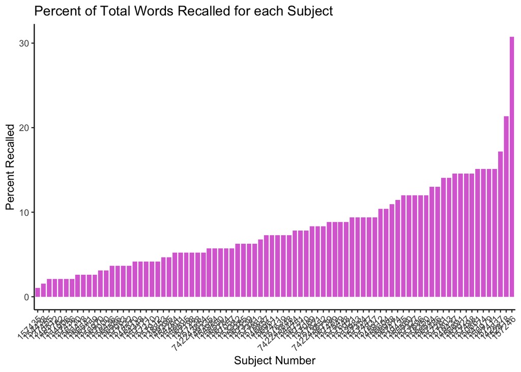

```r
#recall by task
library(dplyr)



sf11_total_2<- sf11_total_final %>%
  group_by(subject) %>%
  mutate(recall_percent2 = sum(recalls_final)/192*100) %>%
  summarise(mean_rec = mean(recall_percent2, na.rm = TRUE))


#plot of each subjects recall in order
sf11_total_2 %>%
  ggplot(aes(x = reorder(as.character(subject), mean_rec), y = mean_rec))+
  geom_col(fill = "orchid", width = .8)+
  theme_classic()+
  theme(axis.text.x = element_text(angle = 45,hjust = 1))+
  labs(title    = "Percent of Total Words Recalled for each Subject",
         x        = "Subject Number",
         y        = "Percent Recalled")
```

```r
mean_recall11_fin <- mean(sf11_total_2$mean_rec, na.rm = TRUE)
mean_recall11_fin
```

```
## [1] 8.079117
```

```r
sd_11 <-sd(sf11_total_2$mean_rec, na.rm = TRUE)
```

```r
#means between same and novel

sf11_total_final_between<- sf11_total_final %>%
  group_by(subject, between_condition) %>%
  mutate(recall_percent2 = sum(recalls_final)/192*100) %>%
  summarise(mean_rec = mean(recall_percent2, na.rm = TRUE))
sf11_total_final_between_same <- sf11_total_final_between %>%
  filter(between_condition == "same")


mean_recall11_fin_same<- mean(sf11_total_final_between_same$mean_rec, na.rm = TRUE)
mean_recall11_fin_same
```

```
## [1] 8.511179
```

```r
sf11_total_final_between_novel <- sf11_total_final_between %>%
  filter(between_condition == "novel")

mean_recall11_fin_novel<- mean(sf11_total_final_between_novel$mean_rec, na.rm = TRUE)
mean_recall11_fin_novel
```

```
## [1] 7.667151
```

```r
t.test(sf11_total_final_between_same$mean_rec, sf11_total_final_between_novel$mean_rec)
```

```
##
##  Welch Two Sample t-test
##
## data:  sf11_total_final_between_same$mean_rec and sf11_total_final_between_novel$mean_rec
## t = 0.77397, df = 77.121, p-value = 0.4413
## alternative hypothesis: true difference in means is not equal to 0
## 95 percent confidence interval:
##  -1.327404  3.015459
## sample estimates:
## mean of x mean of y
##  8.511179  7.667151
```

```r
cohensD(mean_rec~ between_condition, sf11_total_final_between)
```

```
## [1] 0.1677352
```

```r
#separate by between condition
sf11_total_final2 <-sf11_total_final %>%
  mutate(between_condition = case_when(blockcode == "control_mid_same" ~ "same",
                                         blockcode == "control_high_same" ~"same",
                                         blockcode == "high_control_same" ~"same",
                                         blockcode == "mid_control_same" ~"same",
                                       blockcode == "control_mid_novel" ~ "novel",
                                         blockcode == "control_high_novel" ~"novel",
                                         blockcode == "high_control_novel" ~"novel",
                                         blockcode == "mid_control_novel" ~"novel")) %>%
  filter(task_switch == "switch" & condition == "high"|task_switch == "repeat" & condition == "high"|task_switch == "start" & condition == "high"| task_switch == "switch" & condition == "mid"| task_switch == "repeat" & condition == "mid"| task_switch == "start" & condition == "mid"|task_switch == "repeat" & condition == "cont_high"| task_switch == "start" & condition == "cont_high"| task_switch == "repeat" & condition == "cont_mid"| task_switch == "start" & condition == "cont_mid")


sf11_total_same_fin <- sf11_total_final2 %>%
  filter(between_condition == "same")


sf11_total_novel_fin <- sf11_total_final2 %>%
  filter(between_condition == "novel")
```

```r
model_condition_total_final_3w<- glmer(recalls_final~condition_mh*condition_control*between_condition +list_half+blocknum_contin + (1|subject)+ (1|word_enc), family = binomial, data = sf11_total_final2)
summary(model_condition_total_final_3w)
```

```
## Generalized linear mixed model fit by maximum likelihood (Laplace
##   Approximation) [glmerMod]
##  Family: binomial  ( logit )
## Formula:
## recalls_final ~ condition_mh * condition_control * between_condition +
##     list_half + blocknum_contin + (1 | subject) + (1 | word_enc)
##    Data: sf11_total_final2
##
##      AIC      BIC   logLik deviance df.resid
##   8469.4   8561.6  -4222.7   8445.4    15968
##
## Scaled residuals:
##     Min      1Q  Median      3Q     Max
## -1.3043 -0.3191 -0.2390 -0.1742  9.1615
##
## Random effects:
##  Groups   Name        Variance Std.Dev.
##  word_enc (Intercept) 0.2742   0.5236
##  subject  (Intercept) 0.3944   0.6280
## Number of obs: 15980, groups:  word_enc, 240; subject, 84
##
## Fixed effects:
##                                                                Estimate
## (Intercept)                                                   -3.606322
## condition_mhmid                                               -0.036480
## condition_controlswitch                                       -0.192073
## between_conditionsame                                         -0.013061
## list_halfsecond_half                                          -0.005951
## blocknum_contin                                                0.188878
## condition_mhmid:condition_controlswitch                        0.144325
## condition_mhmid:between_conditionsame                          0.188497
## condition_controlswitch:between_conditionsame                  0.326937
## condition_mhmid:condition_controlswitch:between_conditionsame -0.310601
##                                                               Std. Error
## (Intercept)                                                     0.154367
## condition_mhmid                                                 0.118654
## condition_controlswitch                                         0.120645
## between_conditionsame                                           0.183688
## list_halfsecond_half                                            0.059015
## blocknum_contin                                                 0.013390
```

[output cut: 46 more lines]

```
## blcknm_cntn   -0.463 -0.001  -0.005   0.007  0.004
## cndtn_mhmd:c_  0.261 -0.696  -0.711  -0.221 -0.008  0.005
## cndtn_mhmd:b_  0.273 -0.706  -0.341  -0.467 -0.006 -0.012  0.492
## cndtn_cnt:_    0.261 -0.345  -0.715  -0.462  0.002  0.004  0.509
## cndtn_m:_:_   -0.187  0.501   0.512   0.331  0.005 -0.004 -0.719
##               cndtn_mhmd:b_ cndtn_c:_
## condtn_mhmd
## cndtn_cntrl
## btwn_cndtns
## lst_hlfscn_
## blcknm_cntn
## cndtn_mhmd:c_
## cndtn_mhmd:b_
## cndtn_cnt:_    0.507
## cndtn_m:_:_   -0.708        -0.715
```

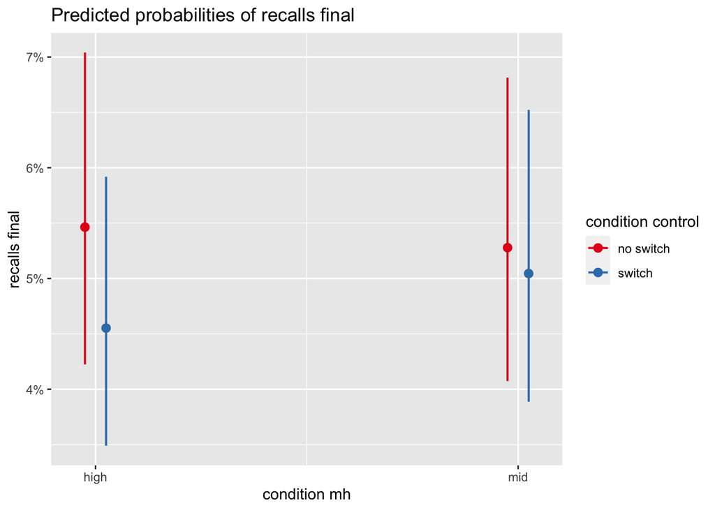

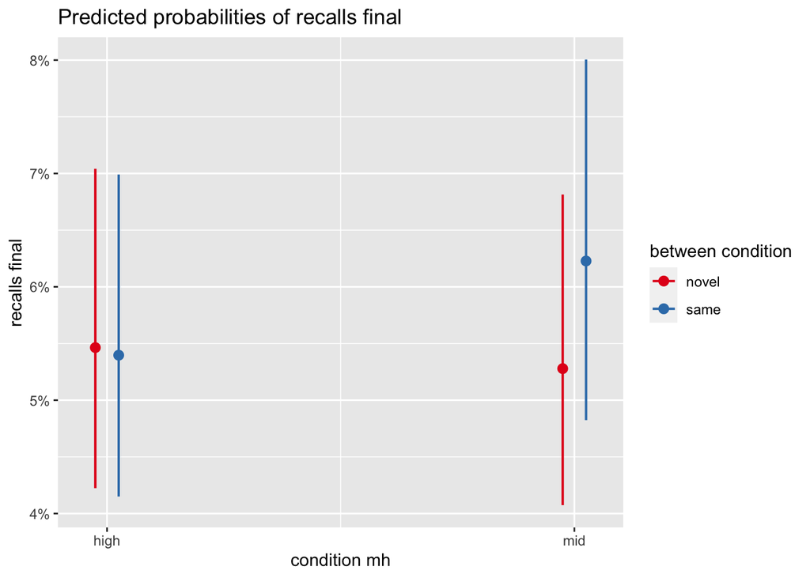

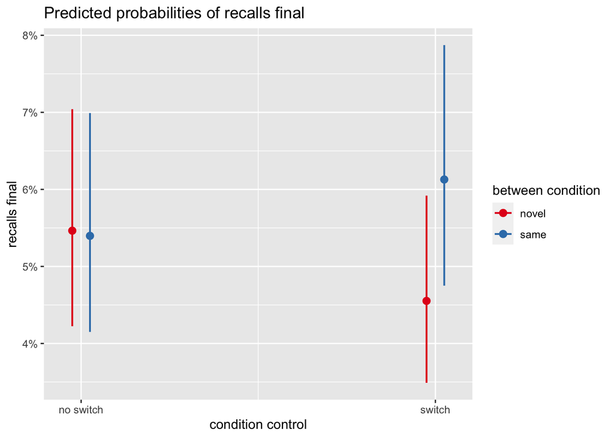

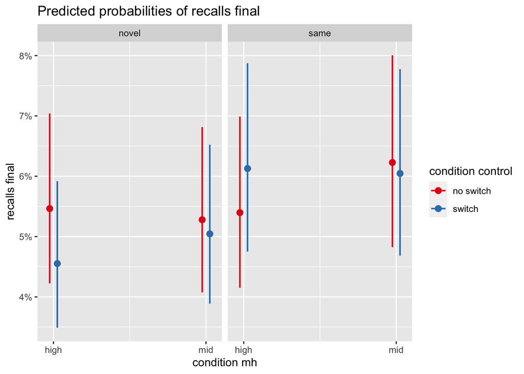

```r
plot_model(model_condition_total_final_3w, type = "int")
```

```r
#SAME

#plot average recalls for task and condition

#separate control into high and mid paired
#no switch items in the control
#difference score error bars same

sf12_total_tally_same <- sf11_total_same_fin %>%
  group_by(subject, condition) %>%
  tally()



sf12_total_same_fin2 <- sf11_total_same_fin %>%
  dplyr:: select(subject, condition, trialcode, sum_recall, recalls_final) %>%
  group_by(subject, condition) %>%
  mutate(sum_recall2 = sum(recalls_final)) %>%
  summarise(mean_rec_cond = mean(sum_recall2))
merged_same <- merge(sf12_total_same_fin2,sf12_total_tally_same)


merged_same_final<- merged_same %>%
  mutate(prop_cond = mean_rec_cond/n)

difference_error_same_fin <- merged_same_final %>%
  dplyr::select(subject, condition, prop_cond) %>%
  reshape(idvar = "subject", timevar = "condition", direction = "wide") %>%
  group_by(subject) %>%
  mutate(diff_cont_high = sum(prop_cond.high- prop_cond.cont_high)) %>%
  mutate(diff_cont_mid = sum(prop_cond.mid- prop_cond.cont_mid))




se_cont_high_same_fin <- std.error(difference_error_same_fin$diff_cont_high)

se_cont_mid_same_fin <- std.error(difference_error_same_fin$diff_cont_mid)


same_fin_df = data.frame(condition = c("control (mid)", "mid", "control (high)", "high"), n = c(41,41,41,41), mean = c(0.08960764, 0.08841463, 0.07741251, 0.08790650), standerr = c(0.009712275, 0.009712275, 0.008166214, 0.008166214),between_condition = c("same", "same", "same", "same"))

same_fin_df<- same_fin_df %>%
  mutate(condition = fct_relevel(condition, "control (mid)", "mid", "control (high)", "high"))

fin_within_same <- same_fin_df %>%
  ggplot(aes(x = condition, y = mean)) +
  geom_col(width = .7, aes(fill = condition), alpha = .8, color = "black", linewidth = .3) +
  labs(title    = "Percentage of Recalls by Condition",
         x        = "Condition",
         y        = "Percent Recalled")+
  theme_classic()+
  geom_errorbar(width=.1, position=position_dodge(.9), aes(ymin=mean-standerr, ymax=mean+standerr))+
scale_y_continuous(labels = scales::percent_format(accuracy = 1L), expand = c(0,0))+
  scale_x_discrete(labels=c("control" = "Control","mid"= "Low Switch", "high" = "High Switch"))+
    scale_fill_manual(values = c("lightgreen", "green4", "lavender", "darkorchid4"))
```

```r
#model for the just same condition

model_condition_same_11<- glmer(recalls_final~condition +list_half+blocknum_contin + (1|subject)+ (1|word_enc), family = binomial, data = sf11_total_same_fin)
summary(model_condition_same_11)
```

```
## Generalized linear mixed model fit by maximum likelihood (Laplace
##   Approximation) [glmerMod]
##  Family: binomial  ( logit )
## Formula: recalls_final ~ condition + list_half + blocknum_contin + (1 |
##     subject) + (1 | word_enc)
##    Data: sf11_total_same_fin
##
##      AIC      BIC   logLik deviance df.resid
##   4355.1   4410.9  -2169.6   4339.1     7888
##
## Scaled residuals:
##     Min      1Q  Median      3Q     Max
## -0.8765 -0.3305 -0.2517 -0.1856  7.9991
##
## Random effects:
##  Groups   Name        Variance Std.Dev.
##  word_enc (Intercept) 0.2179   0.4668
##  subject  (Intercept) 0.2800   0.5292
## Number of obs: 7896, groups:  word_enc, 240; subject, 41
##
## Fixed effects:
##                      Estimate Std. Error z value            Pr(>|z|)
## (Intercept)          -3.76436    0.16724 -22.509 <0.0000000000000002 ***
## conditioncont_mid     0.14095    0.11913   1.183               0.237
## conditionhigh         0.13367    0.11795   1.133               0.257
## conditionmid          0.11711    0.11833   0.990               0.322
## list_halfsecond_half  0.01637    0.08200   0.200               0.842
## blocknum_contin       0.22153    0.01894  11.699 <0.0000000000000002 ***
## ---
## Signif. codes:  0 '***' 0.001 '**' 0.01 '*' 0.05 '.' 0.1 ' ' 1
##
## Correlation of Fixed Effects:
##             (Intr) cndtn_ cndtnh cndtnm lst_h_
## cndtncnt_md -0.363
## conditinhgh -0.376  0.529
## conditionmd -0.362  0.537  0.534
## lst_hlfscn_ -0.238  0.003 -0.010 -0.015
## blcknm_cntn -0.612 -0.024  0.001 -0.021  0.002
```

```r
r2glmm::r2beta(model_condition_same_11, partial = TRUE)
```

```
##                 Effect   Rsq upper.CL lower.CL
## 1                Model 0.017    0.024    0.013
## 6      blocknum_contin 0.017    0.023    0.012
## 2    conditioncont_mid 0.000    0.001    0.000
## 3        conditionhigh 0.000    0.001    0.000
## 4         conditionmid 0.000    0.001    0.000
## 5 list_halfsecond_half 0.000    0.001    0.000
```

```r
model_condition_same_11_2<- glmer(recalls_final~condition_mh*condition_control +list_half+blocknum_contin + (1|subject)+ (1|word_enc), family = binomial, data = sf11_total_same_fin)
summary(model_condition_same_11_2)
```

```
## Generalized linear mixed model fit by maximum likelihood (Laplace
##   Approximation) [glmerMod]
##  Family: binomial  ( logit )
## Formula: recalls_final ~ condition_mh * condition_control + list_half +
##     blocknum_contin + (1 | subject) + (1 | word_enc)
##    Data: sf11_total_same_fin
##
##      AIC      BIC   logLik deviance df.resid
##   4355.1   4410.9  -2169.6   4339.1     7888
##
## Scaled residuals:
##     Min      1Q  Median      3Q     Max
## -0.8765 -0.3305 -0.2517 -0.1856  7.9992
##
## Random effects:
##  Groups   Name        Variance Std.Dev.
##  word_enc (Intercept) 0.2179   0.4668
##  subject  (Intercept) 0.2800   0.5292
## Number of obs: 7896, groups:  word_enc, 240; subject, 41
##
## Fixed effects:
##                                         Estimate Std. Error z value
## (Intercept)                             -3.76440    0.16724 -22.509
## condition_mhmid                          0.14098    0.11913   1.183
## condition_controlswitch                  0.13378    0.11795   1.134
## list_halfsecond_half                     0.01635    0.08200   0.199
## blocknum_contin                          0.22153    0.01894  11.699
## condition_mhmid:condition_controlswitch -0.15760    0.16410  -0.960
##                                                    Pr(>|z|)
## (Intercept)                             <0.0000000000000002 ***
## condition_mhmid                                       0.237
## condition_controlswitch                               0.257
## list_halfsecond_half                                  0.842
## blocknum_contin                         <0.0000000000000002 ***
## condition_mhmid:condition_controlswitch               0.337
## ---
## Signif. codes:  0 '***' 0.001 '**' 0.01 '*' 0.05 '.' 0.1 ' ' 1
##
## Correlation of Fixed Effects:
##             (Intr) cndtn_m cndtn_c lst_h_ blckn_
## condtn_mhmd -0.363
## cndtn_cntrl -0.376  0.530
## lst_hlfscn_ -0.238  0.003  -0.010
## blcknm_cntn -0.612 -0.024   0.001   0.002
## cndtn_mhm:_  0.273 -0.719  -0.718  -0.006  0.001
```

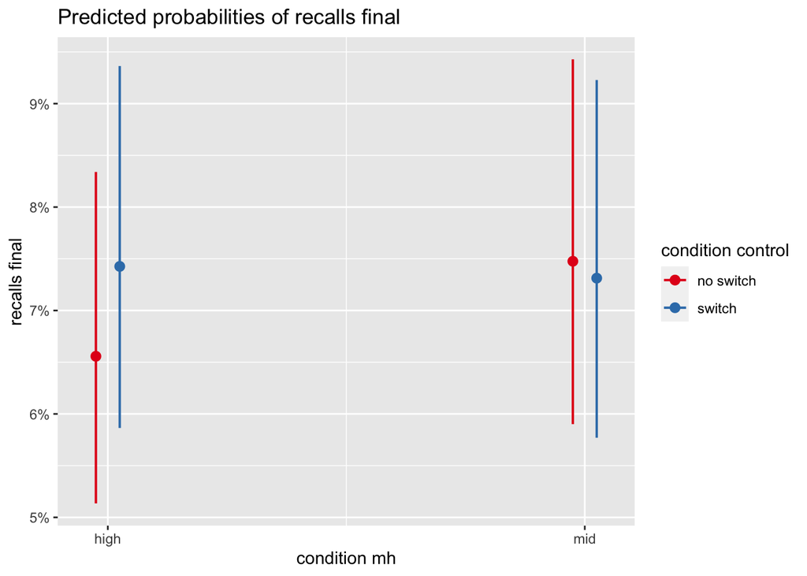

```r
plot_model(model_condition_same_11_2, type = "int")
```

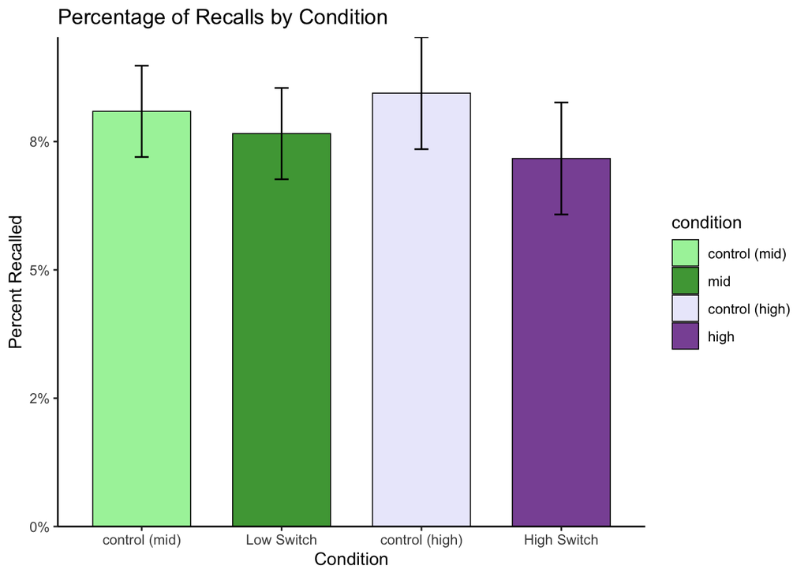

```r
#NOVEL

#plot average recalls for task and condition

#separate control into high and mid paired
#no switch items in the control
#difference score error bars novel

sf11_total_tally_novel <- sf11_total_novel_fin %>%
  group_by(subject, condition) %>%
  tally()



sf11_total_novel_fin2 <- sf11_total_novel_fin %>%
  dplyr:: select(subject, condition, trialcode, sum_recall, recalls_final) %>%
  group_by(subject, condition) %>%
  mutate(sum_recall2 = sum(recalls_final)) %>%
  summarise(mean_rec_cond = mean(sum_recall2))
merged_novel <- merge(sf11_total_novel_fin2,sf11_total_tally_novel)


merged_novel_final <- merged_novel %>%
  mutate(prop_cond = mean_rec_cond/n)

difference_error_nov_fin <- merged_novel_final %>%
  dplyr::select(subject, condition, prop_cond) %>%
  reshape(idvar = "subject", timevar = "condition", direction = "wide") %>%
  group_by(subject) %>%
  mutate(diff_cont_high = sum(prop_cond.high- prop_cond.cont_high)) %>%
  mutate(diff_cont_mid = sum(prop_cond.mid- prop_cond.cont_mid))



se_cont_high_nov_fin <- std.error(difference_error_nov_fin$diff_cont_high)

se_cont_mid_nov_fin <- std.error(difference_error_nov_fin$diff_cont_mid)


nov_fin_df = data.frame(condition = c("control (mid)", "mid", "control (high)", "high"), n = c(43,43,43,43), mean = c(0.08088979, 0.07655039, 0.08442872, 0.07170543), standerr = c(0.008895648, 0.008895648, 0.01091132, 0.01091132), between_condition = c("novel", "novel", "novel", "novel"))

nov_fin_df<- nov_fin_df %>%
  mutate(condition = fct_relevel(condition, "control (mid)", "mid", "control (high)", "high"))

nov_fin_df %>%
  ggplot(aes(x = condition, y = mean)) +
  geom_col(width = .7, aes(fill = condition), alpha = .8, color = "black", linewidth = .3) +
  labs(title    = "Percentage of Recalls by Condition",
         x        = "Condition",
         y        = "Percent Recalled")+
  theme_classic()+
  geom_errorbar(width=.1, position=position_dodge(.9), aes(ymin=mean-standerr, ymax=mean+standerr))+
scale_y_continuous(labels = scales::percent_format(accuracy = 1L), expand = c(0,0))+
  scale_x_discrete(labels=c("control" = "Control","mid"= "Low Switch", "high" = "High Switch"))+
    scale_fill_manual(values = c("lightgreen", "green4", "lavender", "darkorchid4"))
```

```r
#model for the just novel condition


sf11_total_novel_fin<- sf11_total_novel_fin %>%
  mutate(condition = fct_relevel(condition, "high", "mid", "cont_high", "cont_mid"))
model_condition_novel_11<- glmer(recalls_final~condition +list_half+blocknum_contin + (1|subject)+ (1|word_enc), family = binomial, data = sf11_total_novel_fin)
summary(model_condition_novel_11)
```

```
## Generalized linear mixed model fit by maximum likelihood (Laplace
##   Approximation) [glmerMod]
##  Family: binomial  ( logit )
## Formula: recalls_final ~ condition + list_half + blocknum_contin + (1 |
##     subject) + (1 | word_enc)
##    Data: sf11_total_novel_fin
##
##      AIC      BIC   logLik deviance df.resid
##   4150.4   4206.3  -2067.2   4134.4     8076
##
## Scaled residuals:
##     Min      1Q  Median      3Q     Max
## -1.1786 -0.3061 -0.2303 -0.1700  7.8415
##
## Random effects:
##  Groups   Name        Variance Std.Dev.
##  word_enc (Intercept) 0.3131   0.5596
##  subject  (Intercept) 0.4980   0.7057
## Number of obs: 8084, groups:  word_enc, 240; subject, 43
##
## Fixed effects:
##                      Estimate Std. Error z value            Pr(>|z|)
## (Intercept)          -3.54851    0.18054 -19.655 <0.0000000000000002 ***
## conditioncont_mid     0.06391    0.11867   0.539               0.590
## conditionhigh        -0.08995    0.12101  -0.743               0.457
## conditioncont_high    0.09467    0.11801   0.802               0.422
## list_halfsecond_half -0.02892    0.08438  -0.343               0.732
## blocknum_contin       0.15560    0.01888   8.243 <0.0000000000000002 ***
## ---
## Signif. codes:  0 '***' 0.001 '**' 0.01 '*' 0.05 '.' 0.1 ' ' 1
##
## Correlation of Fixed Effects:
##             (Intr) cndtncnt_m cndtnh cndtncnt_h lst_h_
## cndtncnt_md -0.336
## conditinhgh -0.318  0.490
## cndtncnt_hg -0.335  0.502      0.496
## lst_hlfscn_ -0.240  0.034      0.005  0.022
## blcknm_cntn -0.542 -0.004     -0.011 -0.006      0.004
```

```r
r2glmm::r2beta(model_condition_novel_11, partial = TRUE)
```

```
##                 Effect   Rsq upper.CL lower.CL
## 1                Model 0.008    0.013    0.005
## 6      blocknum_contin 0.008    0.012    0.004
## 4   conditioncont_high 0.000    0.001    0.000
## 3        conditionhigh 0.000    0.001    0.000
## 2    conditioncont_mid 0.000    0.001    0.000
## 5 list_halfsecond_half 0.000    0.001    0.000
```

```r
sf11_total_novel_fin<- sf11_total_novel_fin %>%
  mutate(condition = fct_relevel(condition, "high", "mid", "cont_high", "cont_mid"))

model_condition_novel_11_2<- glmer(recalls_final~condition_mh*condition_control +list_half+blocknum_contin + (1|subject)+ (1|word_enc), family = binomial, data = sf11_total_novel_fin)
summary(model_condition_novel_11_2)
```

```
## Generalized linear mixed model fit by maximum likelihood (Laplace
##   Approximation) [glmerMod]
##  Family: binomial  ( logit )
## Formula: recalls_final ~ condition_mh * condition_control + list_half +
##     blocknum_contin + (1 | subject) + (1 | word_enc)
##    Data: sf11_total_novel_fin
##
##      AIC      BIC   logLik deviance df.resid
##   4150.4   4206.3  -2067.2   4134.4     8076
##
## Scaled residuals:
##     Min      1Q  Median      3Q     Max
## -1.1786 -0.3061 -0.2303 -0.1700  7.8416
##
## Random effects:
##  Groups   Name        Variance Std.Dev.
##  word_enc (Intercept) 0.3131   0.5596
##  subject  (Intercept) 0.4980   0.7057
## Number of obs: 8084, groups:  word_enc, 240; subject, 43
##
## Fixed effects:
##                                         Estimate Std. Error z value
## (Intercept)                             -3.45384    0.17962 -19.229
## condition_mhmid                         -0.03074    0.11805  -0.260
## condition_controlswitch                 -0.18462    0.11998  -1.539
## list_halfsecond_half                    -0.02891    0.08438  -0.343
## blocknum_contin                          0.15560    0.01888   8.243
## condition_mhmid:condition_controlswitch  0.12072    0.16879   0.715
##                                                    Pr(>|z|)
## (Intercept)                             <0.0000000000000002 ***
## condition_mhmid                                       0.795
## condition_controlswitch                               0.124
## list_halfsecond_half                                  0.732
## blocknum_contin                         <0.0000000000000002 ***
## condition_mhmid:condition_controlswitch               0.474
## ---
## Signif. codes:  0 '***' 0.001 '**' 0.01 '*' 0.05 '.' 0.1 ' ' 1
##
## Correlation of Fixed Effects:
##             (Intr) cndtn_m cndtn_c lst_h_ blckn_
## condtn_mhmd -0.328
## cndtn_cntrl -0.309  0.483
## lst_hlfscn_ -0.226  0.011  -0.017
## blcknm_cntn -0.549  0.002  -0.006   0.004
## cndtn_mhm:_  0.225 -0.697  -0.711  -0.012  0.007
```

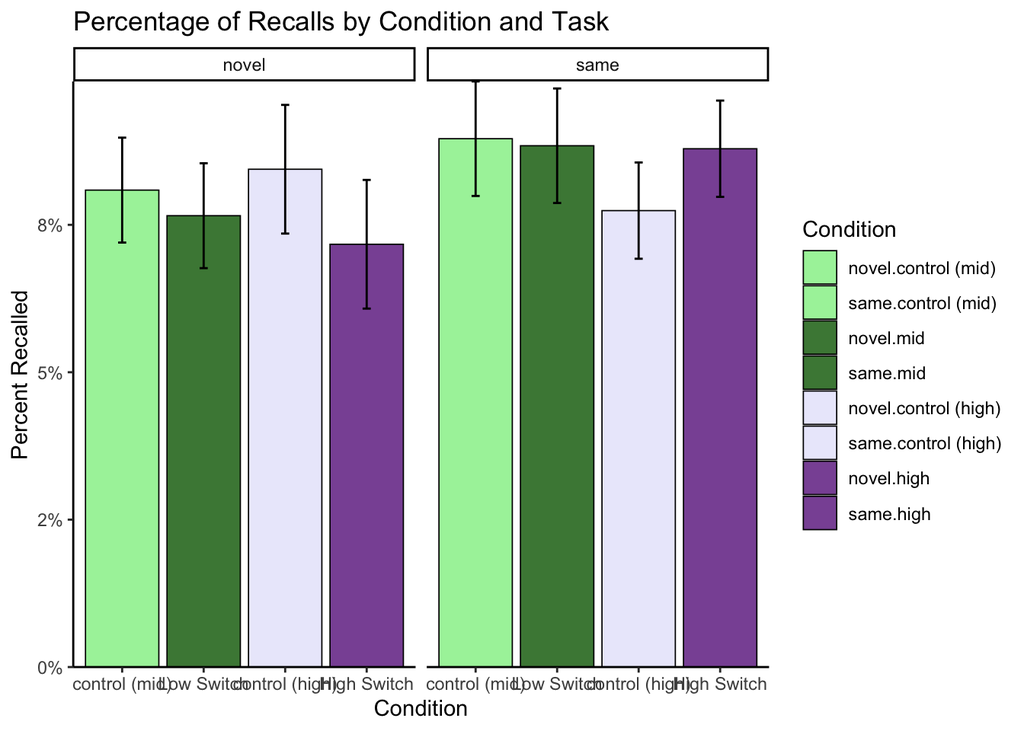

```r
between_condition_bind_final_v1 <- rbind(same_fin_df, nov_fin_df)


between_condition_bind_final_v1 %>%
  ggplot(aes(x = condition, fill = interaction(between_condition,condition), y = mean)) +
  geom_bar(position="dodge", stat="identity", color = "black", linewidth = .3, alpha = .8) +
  labs(title    = "Percentage of Recalls by Condition and Task",
         x        = "Condition",
         y        = "Percent Recalled")+
  theme_classic()+
  geom_errorbar(width=.1, position=position_dodge(.9), aes(ymin=mean-standerr, ymax=mean+standerr))+
  scale_y_continuous(labels = scales::percent_format(accuracy = 1L), expand = c(0,0))+
  scale_x_discrete(labels=c("cont_mid" = "Control (Low)","mid"= "Low Switch", "cont_high" = "Control (High)", "high" = "High Switch"))+
  scale_fill_manual(name = "Condition", values=c("lightgreen", "lightgreen", "darkgreen", "darkgreen", "lavender", "lavender","darkorchid4", "darkorchid4")) +
  facet_wrap(.~between_condition)
```

```r
#model comparing same and novel

model_condition_total_11<- glmer(recalls_final~condition*between_condition +list_half+blocknum_contin + (1|subject)+ (1|word_enc), family = binomial, data = sf11_total_final2)
summary(model_condition_total_11)
```

```
## Generalized linear mixed model fit by maximum likelihood (Laplace
##   Approximation) [glmerMod]
##  Family: binomial  ( logit )
## Formula:
## recalls_final ~ condition * between_condition + list_half + blocknum_contin +
##     (1 | subject) + (1 | word_enc)
##    Data: sf11_total_final2
##
##      AIC      BIC   logLik deviance df.resid
##   8469.4   8561.6  -4222.7   8445.4    15968
##
## Scaled residuals:
##     Min      1Q  Median      3Q     Max
## -1.3041 -0.3191 -0.2390 -0.1742  9.1671
##
## Random effects:
##  Groups   Name        Variance Std.Dev.
##  word_enc (Intercept) 0.2745   0.5239
##  subject  (Intercept) 0.3946   0.6281
## Number of obs: 15980, groups:  word_enc, 240; subject, 84
##
## Fixed effects:
##                                          Estimate Std. Error z value
## (Intercept)                             -3.607093   0.154401 -23.362
## conditioncont_mid                       -0.035573   0.118666  -0.300
## conditionhigh                           -0.191196   0.120660  -1.585
## conditionmid                            -0.083150   0.118679  -0.701
## between_conditionsame                   -0.011882   0.183723  -0.065
## list_halfsecond_half                    -0.005998   0.059014  -0.102
## blocknum_contin                          0.188896   0.013390  14.107
## conditioncont_mid:between_conditionsame  0.187370   0.168056   1.115
## conditionhigh:between_conditionsame      0.325731   0.168726   1.931
## conditionmid:between_conditionsame       0.203492   0.167445   1.215
##                                                    Pr(>|z|)
## (Intercept)                             <0.0000000000000002 ***
## conditioncont_mid                                    0.7644
## conditionhigh                                        0.1131
## conditionmid                                         0.4835
## between_conditionsame                                0.9484
## list_halfsecond_half                                 0.9191
## blocknum_contin                         <0.0000000000000002 ***
## conditioncont_mid:between_conditionsame              0.2649
## conditionhigh:between_conditionsame                  0.0535 .
## conditionmid:between_conditionsame                   0.2243
## ---
## Signif. codes:  0 '***' 0.001 '**' 0.01 '*' 0.05 '.' 0.1 ' ' 1
##
## Correlation of Fixed Effects:
##             (Intr) cndtn_ cndtnh cndtnm btwn_c lst_h_ blckn_ cnd_:_ cndtnh:_
## cndtncnt_md -0.379
## conditinhgh -0.364  0.482
## conditionmd -0.376  0.495  0.482
## btwn_cndtns -0.584  0.318  0.311  0.318
## lst_hlfscn_ -0.184  0.008 -0.012 -0.015 -0.001
## blcknm_cntn -0.463 -0.001 -0.005  0.001  0.007  0.004
## cndtncnt_:_  0.273 -0.707 -0.341 -0.350 -0.467 -0.006 -0.012
## cndtnhgh:b_  0.261 -0.345 -0.715 -0.344 -0.462  0.002  0.004  0.507
## cndtnmd:bt_  0.273 -0.351 -0.341 -0.708 -0.468  0.004 -0.013  0.516  0.508
## optimizer (Nelder_Mead) convergence code: 0 (OK)
## Model failed to converge with max|grad| = 0.0269738 (tol = 0.002, component 1)
```

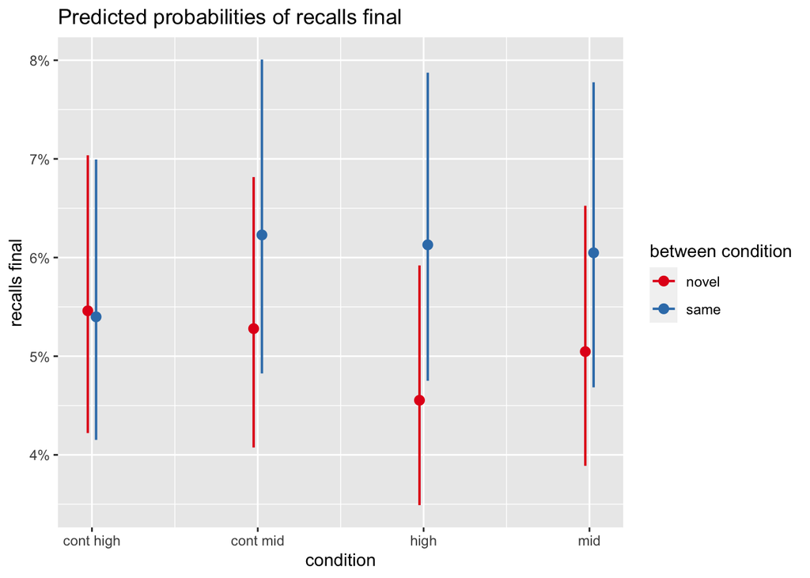

```r
plot_model(model_condition_total_11, type = "int")
```

```r
sf11_total_final2_high <- sf11_total_final2 %>%
  filter(condition == "high"| condition == "cont_high")


model_condition_total_11<- glmer(recalls_final~condition*between_condition +list_half+blocknum_contin + (1|subject)+ (1|word_enc), family = binomial, data = sf11_total_final2_high)
summary(model_condition_total_11)
```

```
## Generalized linear mixed model fit by maximum likelihood (Laplace
##   Approximation) [glmerMod]
##  Family: binomial  ( logit )
## Formula:
## recalls_final ~ condition * between_condition + list_half + blocknum_contin +
##     (1 | subject) + (1 | word_enc)
##    Data: sf11_total_final2_high
##
##      AIC      BIC   logLik deviance df.resid
##   4131.6   4187.4  -2057.8   4115.6     7982
##
## Scaled residuals:
##     Min      1Q  Median      3Q     Max
## -1.2247 -0.3099 -0.2243 -0.1631  8.4339
##
## Random effects:
##  Groups   Name        Variance Std.Dev.
##  word_enc (Intercept) 0.3104   0.5571
##  subject  (Intercept) 0.6155   0.7846
## Number of obs: 7990, groups:  word_enc, 240; subject, 84
##
## Fixed effects:
##                                      Estimate Std. Error z value
## (Intercept)                         -3.791864   0.195893 -19.357
## conditionhigh                       -0.180465   0.120915  -1.492
## between_conditionsame               -0.006107   0.213196  -0.029
## list_halfsecond_half                -0.003455   0.084531  -0.041
## blocknum_contin                      0.206345   0.020655   9.990
## conditionhigh:between_conditionsame  0.316231   0.169156   1.869
##                                                Pr(>|z|)
## (Intercept)                         <0.0000000000000002 ***
## conditionhigh                                    0.1356
## between_conditionsame                            0.9771
## list_halfsecond_half                             0.9674
## blocknum_contin                     <0.0000000000000002 ***
## conditionhigh:between_conditionsame              0.0616 .
## ---
## Signif. codes:  0 '***' 0.001 '**' 0.01 '*' 0.05 '.' 0.1 ' ' 1
##
## Correlation of Fixed Effects:
##             (Intr) cndtnh btwn_c lst_h_ blckn_
## conditinhgh -0.285
## btwn_cndtns -0.537  0.269
## lst_hlfscn_ -0.208 -0.023 -0.002
## blcknm_cntn -0.564 -0.005  0.005  0.006
## cndtnhgh:b_  0.205 -0.714 -0.400  0.006  0.006
```

```r
r2glmm::r2beta(model_condition_total_11, partial = TRUE)
```

```
##                                Effect   Rsq upper.CL lower.CL
## 1                               Model 0.013    0.019    0.009
## 5                     blocknum_contin 0.013    0.018    0.008
## 6 conditionhigh:between_conditionsame 0.000    0.002    0.000
## 2                       conditionhigh 0.000    0.001    0.000
## 3               between_conditionsame 0.000    0.001    0.000
## 4                list_halfsecond_half 0.000    0.001    0.000
```

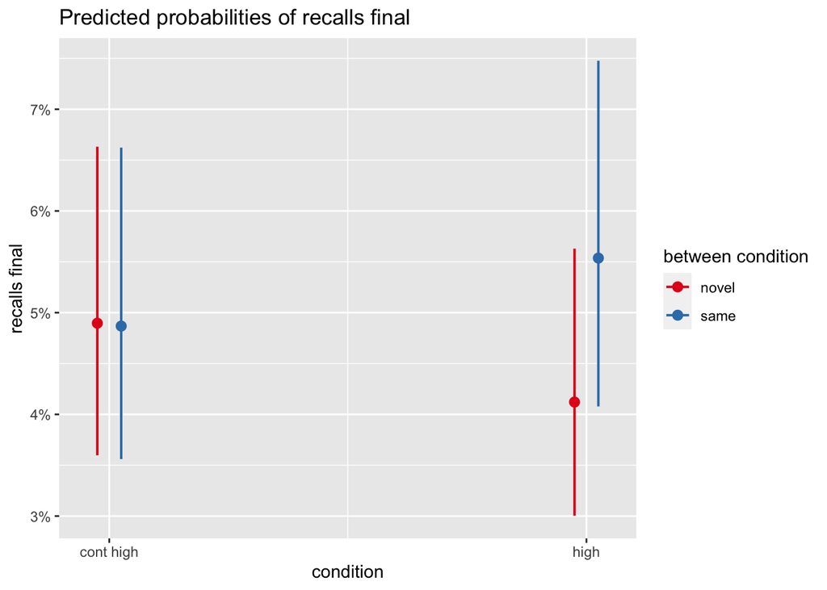

```r
plot_model(model_condition_total_11, type = "int")
```

```r
#model 2x2 mid/high and switch/repeat

sf11_total_final3<-sf11_total_final2 %>%
  filter(condition == "high" | condition == "mid") %>%
  filter(task_switch == "switch" | task_switch == "repeat")



#same

sf11_total_final_same_transition<-sf11_total_final2 %>%
  filter(condition == "high" | condition == "mid") %>%
  filter(task_switch == "switch" | task_switch == "repeat") %>%
  filter(between_condition == "same")

model_transition_final_11_same<- glmer(recalls_final~condition*task_switch + list_half+(1|subject)+ (1|word_enc), family = binomial, data = sf11_total_final_same_transition)
summary(model_transition_final_11_same)
```

```
## Generalized linear mixed model fit by maximum likelihood (Laplace
##   Approximation) [glmerMod]
##  Family: binomial  ( logit )
## Formula: recalls_final ~ condition * task_switch + list_half + (1 | subject) +
##     (1 | word_enc)
##    Data: sf11_total_final_same_transition
##
##      AIC      BIC   logLik deviance df.resid
##   2230.7   2274.6  -1108.4   2216.7     3857
##
## Scaled residuals:
##     Min      1Q  Median      3Q     Max
## -0.5923 -0.3233 -0.2723 -0.2297  5.1994
##
## Random effects:
##  Groups   Name        Variance Std.Dev.
##  word_enc (Intercept) 0.2117   0.4601
##  subject  (Intercept) 0.2292   0.4788
## Number of obs: 3864, groups:  word_enc, 240; subject, 41
##
## Fixed effects:
##                                Estimate Std. Error z value            Pr(>|z|)
## (Intercept)                    -2.61837    0.15809 -16.563 <0.0000000000000002
## conditionmid                    0.08869    0.14598   0.608               0.543
## task_switchswitch               0.09513    0.16278   0.584               0.559
## list_halfsecond_half            0.06750    0.11561   0.584               0.559
## conditionmid:task_switchswitch -0.29788    0.26318  -1.132               0.258
##
## (Intercept)                    ***
## conditionmid
## task_switchswitch
## list_halfsecond_half
## conditionmid:task_switchswitch
## ---
## Signif. codes:  0 '***' 0.001 '**' 0.01 '*' 0.05 '.' 0.1 ' ' 1
##
## Correlation of Fixed Effects:
##             (Intr) cndtnm tsk_sw lst_h_
## conditionmd -0.572
## tsk_swtchsw -0.505  0.551
## lst_hlfscn_ -0.374  0.001 -0.030
## cndtnmd:ts_  0.328 -0.554 -0.618 -0.029
```

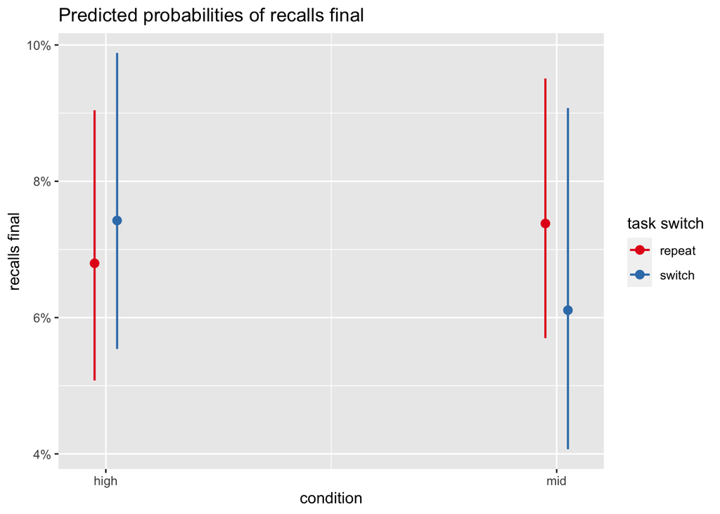

```r
plot_model(model_transition_final_11_same, type = "int")
```

```r
#novel

sf11_total_final_nov_transition<-sf11_total_final2 %>%
  filter(condition == "high" | condition == "mid") %>%
  filter(task_switch == "switch" | task_switch == "repeat") %>%
  filter(between_condition == "novel")

model_transition_final_11_novel<- glmer(recalls_final~condition*task_switch +list_half + blocknum_contin + (1|subject)+ (1|word_enc), family = binomial, data = sf11_total_final_nov_transition)
summary(model_transition_final_11_novel)
```

```
## Generalized linear mixed model fit by maximum likelihood (Laplace
##   Approximation) [glmerMod]
##  Family: binomial  ( logit )
## Formula:
## recalls_final ~ condition * task_switch + list_half + blocknum_contin +
##     (1 | subject) + (1 | word_enc)
##    Data: sf11_total_final_nov_transition
##
##      AIC      BIC   logLik deviance df.resid
##   1976.8   2027.1   -980.4   1960.8     3948
##
## Scaled residuals:
##     Min      1Q  Median      3Q     Max
## -1.0139 -0.2869 -0.2228 -0.1716  7.4033
##
## Random effects:
##  Groups   Name        Variance Std.Dev.
##  word_enc (Intercept) 0.3899   0.6244
##  subject  (Intercept) 0.4999   0.7070
## Number of obs: 3956, groups:  word_enc, 240; subject, 43
##
## Fixed effects:
##                                Estimate Std. Error z value             Pr(>|z|)
## (Intercept)                    -3.84531    0.25063 -15.343 < 0.0000000000000002
## conditionmid                    0.24002    0.16813   1.428                0.153
## task_switchswitch               0.23598    0.18566   1.271                0.204
## list_halfsecond_half            0.06461    0.12993   0.497                0.619
## blocknum_contin                 0.15370    0.02866   5.363          0.000000082
## conditionmid:task_switchswitch -0.28176    0.28728  -0.981                0.327
##
## (Intercept)                    ***
## conditionmid
## task_switchswitch
## list_halfsecond_half
## blocknum_contin                ***
## conditionmid:task_switchswitch
## ---
## Signif. codes:  0 '***' 0.001 '**' 0.01 '*' 0.05 '.' 0.1 ' ' 1
##
## Correlation of Fixed Effects:
##             (Intr) cndtnm tsk_sw lst_h_ blckn_
## conditionmd -0.450
## tsk_swtchsw -0.389  0.580
## lst_hlfscn_ -0.243  0.002 -0.026
## blcknm_cntn -0.597  0.025  0.005 -0.055
## cndtnmd:ts_  0.259 -0.583 -0.645 -0.032  0.003
## optimizer (Nelder_Mead) convergence code: 0 (OK)
## Model failed to converge with max|grad| = 0.00283283 (tol = 0.002, component 1)
```

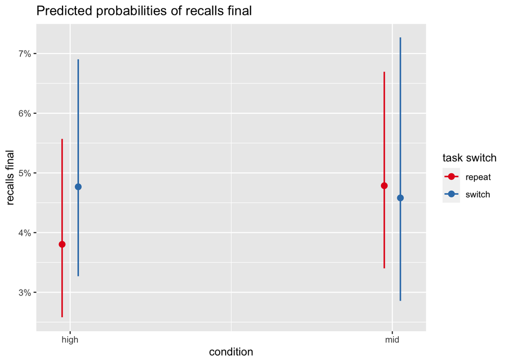

```r
plot_model(model_transition_final_11_novel, type = "int")
```

```r
#total

model_transition_final_11<- glmer(recalls_final~condition*task_switch*between_condition +list_half + blocknum_contin + (1|subject)+ (1|word_enc), family = binomial, data = sf11_total_final3)
summary(model_transition_final_11)
```

```
## Generalized linear mixed model fit by maximum likelihood (Laplace
##   Approximation) [glmerMod]
##  Family: binomial  ( logit )
## Formula: recalls_final ~ condition * task_switch * between_condition +
##     list_half + blocknum_contin + (1 | subject) + (1 | word_enc)
##    Data: sf11_total_final3
##
##      AIC      BIC   logLik deviance df.resid
##   4133.6   4217.2  -2054.8   4109.6     7808
##
## Scaled residuals:
##     Min      1Q  Median      3Q     Max
## -0.9991 -0.3098 -0.2382 -0.1813  7.3240
##
## Random effects:
##  Groups   Name        Variance Std.Dev.
##  word_enc (Intercept) 0.2699   0.5195
##  subject  (Intercept) 0.3744   0.6119
## Number of obs: 7820, groups:  word_enc, 240; subject, 84
##
## Fixed effects:
##                                                      Estimate Std. Error
## (Intercept)                                          -3.91904    0.20148
## conditionmid                                          0.24074    0.16136
## task_switchswitch                                     0.22845    0.17818
## between_conditionsame                                 0.37517    0.22083
## list_halfsecond_half                                  0.06226    0.08551
## blocknum_contin                                       0.18413    0.01916
## conditionmid:task_switchswitch                       -0.27235    0.27553
## conditionmid:between_conditionsame                   -0.17361    0.21889
## task_switchswitch:between_conditionsame              -0.14776    0.24229
## conditionmid:task_switchswitch:between_conditionsame -0.02378    0.38284
##                                                      z value
## (Intercept)                                          -19.451
## conditionmid                                           1.492
## task_switchswitch                                      1.282
## between_conditionsame                                  1.699
## list_halfsecond_half                                   0.728
## blocknum_contin                                        9.609
## conditionmid:task_switchswitch                        -0.988
```

[output cut: 25 more lines]

```
## cndtnmd:bt_  0.392 -0.738 -0.427 -0.623  0.001 -0.025  0.430
## tsk_swtch:_  0.344 -0.426 -0.735 -0.560 -0.002 -0.003  0.476      0.565
## cndtnmd:_:_ -0.215  0.420  0.465  0.355 -0.002  0.000 -0.720     -0.569
##             tsk_:_
## conditionmd
## tsk_swtchsw
## btwn_cndtns
## lst_hlfscn_
## blcknm_cntn
## cndtnmd:ts_
## cndtnmd:bt_
## tsk_swtch:_
## cndtnmd:_:_ -0.633
## optimizer (Nelder_Mead) convergence code: 0 (OK)
## Model failed to converge with max|grad| = 0.0609159 (tol = 0.002, component 1)
```

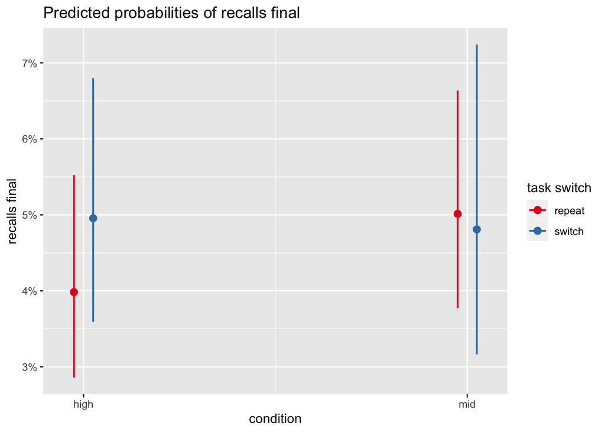

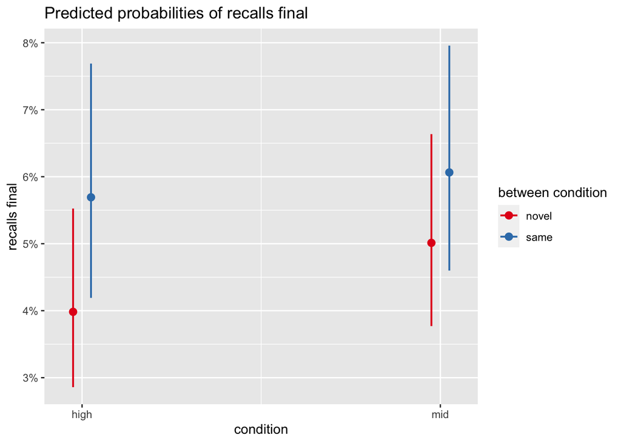

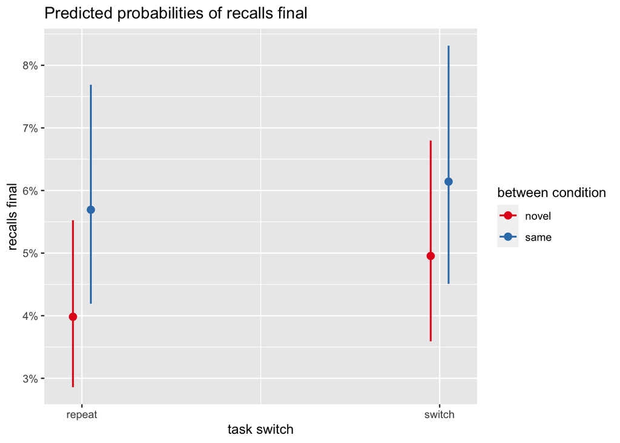

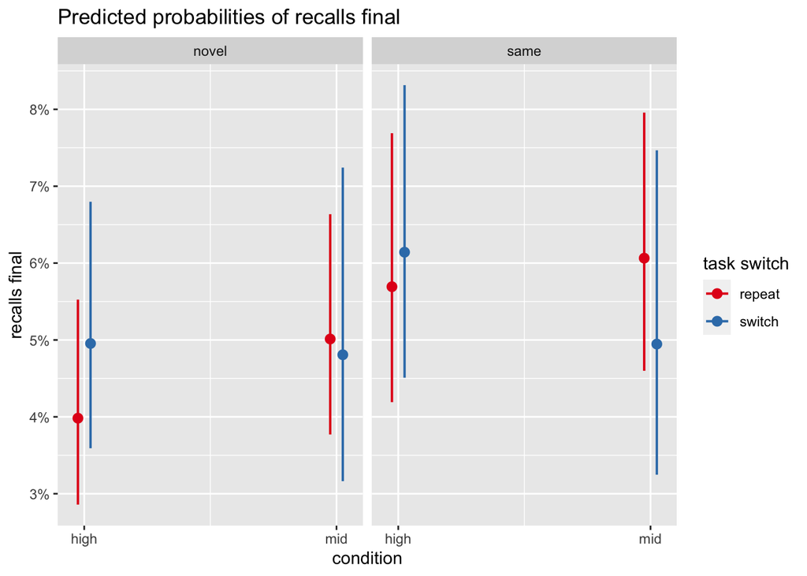

```r
plot_model(model_transition_final_11, type = "int")
```

```r
#boundary vs preboundary- supplemental materials



sf11_total_mid_spc_final<- sf11_total_final2 %>%
  filter(condition == "mid") %>%
  filter(trialnum == "5" | trialnum == "6" |trialnum == "8" |trialnum == "9" |trialnum == "10" |trialnum == "12"| trialnum == "13" |trialnum == "14"| trialnum == "16" |trialnum == "17" |trialnum == "18" |trialnum == "20") %>%
  mutate(trialnum_new = case_when(trialnum == "5" ~ "boundary",
                                  trialnum == "6" ~ "postboundary",
                               trialnum == "8" ~ "preboundary",
                               trialnum == "9" ~ "boundary",
                               trialnum == "10" ~ "postboundary",
                               trialnum == "12" ~ "preboundary",
                               trialnum == "13" ~ "boundary",
                               trialnum == "14" ~ "postboundary",
                               trialnum == "16" ~ "preboundary",
                               trialnum == "17" ~ "boundary",
                               trialnum == "18" ~ "postboundary",
                               trialnum == "20" ~ "preboundary"))



spc_mid_11_tally_final <- sf11_total_mid_spc_final %>%
  group_by(subject, trialnum_new) %>%
  tally()
spc_mid_11_tally_final
```

```
## # A tibble: 252 × 3
## # Groups:   subject [84]
##    subject trialnum_new     n
##      <int> <chr>        <int>
##  1  137455 boundary         8
##  2  137455 postboundary     8
##  3  137455 preboundary      8
##  4  138853 boundary         8
##  5  138853 postboundary     8
##  6  138853 preboundary      8
##  7  139435 boundary         8
##  8  139435 postboundary     8
##  9  139435 preboundary      8
## 10  142837 boundary         8
## # ℹ 242 more rows
```

```r
spc_mid_11_final <- sf11_total_mid_spc_final %>%
  dplyr:: select(subject, trialnum_new, between_condition, recalls_final) %>%
  group_by(subject, trialnum_new, between_condition) %>%
  mutate(sum_recall2 = sum(recalls_final)) %>%
  summarise(mean_rec_cond = mean(sum_recall2))
merged_spc_final <- merge(spc_mid_11_final,spc_mid_11_tally_final)


merged_spc_final <- merged_spc_final %>%
  mutate(prop_cond = mean_rec_cond/n)


merged_spc_final<- merged_spc_final %>%
  mutate(trialnum_new = fct_relevel(trialnum_new, "preboundary", "boundary", "postboundary"))


library(Rmisc)
spc_mid_11_final <- summarySEwithin(merged_spc_final, measurevar="prop_cond", withinvars = c("trialnum_new", "between_condition"),idvar = "subject", na.rm=FALSE, conf.interval=.95)
```

```
## Automatically converting the following non-factors to factors: between_condition
```

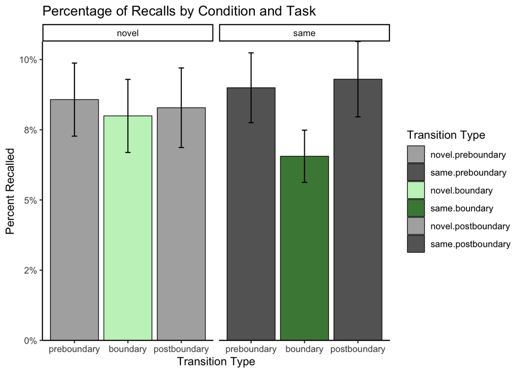

```r
spc_mid_11_final %>%
  ggplot(aes(x = trialnum_new, fill = interaction(between_condition,trialnum_new), y = prop_cond)) +
  geom_bar(position="dodge", stat="identity", color = "black", linewidth = .3, alpha = .8) +
  labs(title    = "Percentage of Recalls by Condition and Task",
         x        = "Transition Type",
         y        = "Percent Recalled")+
  theme_classic()+
  geom_errorbar(width=.1, position=position_dodge(.9), aes(ymin=prop_cond-se, ymax=prop_cond+se))+
  scale_y_continuous(labels = scales::percent_format(accuracy = 1L), expand = c(0,0))+
  scale_fill_manual(name = "Transition Type", values=c("grey60", "grey20", "darkseagreen2", "darkgreen", "grey60", "grey20","lavender", "darkorchid4")) +
  facet_wrap(.~between_condition)
```

```r
#model for boundary information
detach(package:Rmisc)
detach(package:plyr) #MUST RUN THIS

sf11_total_mid_spc_final<- sf11_total_mid_spc_final %>%
  mutate(trialnum_new = fct_relevel(trialnum_new, "boundary", "preboundary", "postboundary"))
sf11_total_mid_spc_final2 <- sf11_total_mid_spc_final %>%
  filter(between_condition == "novel")


sf11_total_mid_spc_3_model_total_final<- glmer(recalls_final~trialnum_new+ blocknum_contin + (1|subject)+ (1|word_enc), family = binomial, data = sf11_total_mid_spc_final2)
summary(sf11_total_mid_spc_3_model_total_final)
```

```
## Generalized linear mixed model fit by maximum likelihood (Laplace
##   Approximation) [glmerMod]
##  Family: binomial  ( logit )
## Formula: recalls_final ~ trialnum_new + blocknum_contin + (1 | subject) +
##     (1 | word_enc)
##    Data: sf11_total_mid_spc_final2
##
##      AIC      BIC   logLik deviance df.resid
##    550.2    579.8   -269.1    538.2     1026
##
## Scaled residuals:
##     Min      1Q  Median      3Q     Max
## -0.7762 -0.2646 -0.2229 -0.1923  4.3385
##
## Random effects:
##  Groups   Name        Variance Std.Dev.
##  word_enc (Intercept) 0.5537   0.7441
##  subject  (Intercept) 0.5192   0.7206
## Number of obs: 1032, groups:  word_enc, 240; subject, 43
##
## Fixed effects:
##                          Estimate Std. Error z value            Pr(>|z|)
## (Intercept)              -3.15201    0.39501  -7.980 0.00000000000000147 ***
## trialnum_newpreboundary   0.07012    0.30595   0.229               0.819
## trialnum_newpostboundary  0.02104    0.30941   0.068               0.946
## blocknum_contin           0.03954    0.05346   0.740               0.460
## ---
## Signif. codes:  0 '***' 0.001 '**' 0.01 '*' 0.05 '.' 0.1 ' ' 1
##
## Correlation of Fixed Effects:
##             (Intr) trlnm_nwpr trlnm_nwps
## trlnm_nwprb -0.382
## trlnm_nwpst -0.369  0.510
## blcknm_cntn -0.622 -0.011     -0.013
```